# Exploratory Data Analysis

Robby Stohel

2025-04-27

**Required Points:**

- Description of the data
- Discussion of missing data
- Exploratory visualizations and/or summary tables
- Results section
- Professional use of notebook

# 1 Introduction

In this section of the project, we will conduct exploratory data analysis (EDA) on the datasets provided by *Home Credit* in their *Kaggle* competition focused on predicting `loan default risk`. Utilizing the CRISP-DM methodology, we aim to gain insights into the factors influencing loan defaults by examining the Application Train and Test table alongside additional data from the Bureau, Credit Card Balance, Previous Applications, and Installments tables. This EDA stage will involve identifying patterns, trends, and relationships within the data, which will inform future modeling efforts and risk assessment strategies. By thoroughly analyzing borrower characteristics and credit behavior, we seek to enhance the understanding of loan default dynamics and improve lending decisions.

# 2 Initial Considerations

## 2.1 Prohibited Factors for Loan Decisions

Lending regulations across various countries prohibit the use of certain personal data when making loan decisions to prevent discrimination. The following list aggregates restricted factors from the *United States, Czech Republic, Slovakia, Kazakhstan, China, Vietnam, Air Bank (Czech Republic), India, Indonesia, and the Philippines* **as these locations were listed as areas of operation for Home Credit based on their website**. These regions have laws and regulations that generally prohibit discrimination based on attributes such as race, ethnicity, religion, gender, age, disability, and social status. Below is a combined and deduplicated list of factors that cannot legally be used to determine loan eligibility.

- **Race**
- **Ethnicity**
- **Religion or belief**
- **Gender**
- **Age (unless related to contract capacity)**
- **Disability**
- **Marital status**
- **Nationality or place of birth**
- **Social status or caste**
- **Receipt of public assistance**
- **Language**
- **Political beliefs**
- **Familial status (in housing-related loans)**
- **Exercising consumer protection rights**

This list provides a broad overview of anti-discrimination factors applicable across multiple jurisdictions. However, specific regulations may vary by country. Using illegal factors in lending decisions can result in lawsuits, regulatory penalties, and reputational damage.

That said, the data we have gathered can still offer valuable insights for other purposes, such as marketing or sales strategies. As such, we can explore alternative uses for this information without needing to exclude the restricted data at this stage.

## 2.2 Performance Measures

When evaluating the predictive accuracy of a logarithic predictive model or other such predictive model, the best metrics depend on the type of outcome variable and the link function used in the model. These measures won’t be used here for exploratory data analysis, but will come in handy during the modeling stage of this project. Below are key metrics based on the GLM model type used in R:

**Outcome:** range between `0` and `1`  
**Common use cases:** Fraud detection, customer churn prediction, credit risk modeling  
**Metrics:**

1. **Accuracy** – Proportion of correctly classified observations.

```
mean(predicted_class == actual_class)
```

2. **AUC-ROC (Area Under the Curve - Receiver Operating Characteristic)** – Measures the model’s ability to distinguish between classes.

```
library(pROC)
roc_curve <- roc(actual_class, predicted_prob)
auc(roc_curve)
```

3. **Precision, Recall, and F1-score** – Especially useful for imbalanced data.

```
library(caret)
confusionMatrix(predicted_class, actual_class)
```

4. **Log-Loss (Negative Log-Likelihood)** – Penalizes incorrect classifications with high confidence.

```
library(Metrics)
logLoss(actual_class, predicted_prob)
```

# 3 Data Sourcing

This assessment will be utilizing the datasets provided by *Home Credit* in their *Kaggle* project to analyze and develop models for predicting default risk among loan applicants. The comprehensive data, which includes various features related to customer demographics, loan characteristics, and previous application histories, will allow me to identify patterns and insights that can enhance predictive accuracy. This analysis will inform risk assessment strategies, ultimately aiming to improve lending decisions and reduce default rates.

## 3.1 Data Dictionary

Here’s the unified and cleaned-up data dictionary formatted in markdown:

**Application Train and Test**

- **SK_ID_CURR**: Unique identifier for each loan application.
- **TARGET**: Indicates whether the client experienced repayment difficulties (1) or not (0).
- **NAME_CONTRACT_TYPE**: Type of loan (e.g., cash loan, revolving loan).
- **CODE_GENDER**: Gender of the applicant.
- **FLAG_OWN_CAR**: Indicator of car ownership by the applicant (Y/N).
- **FLAG_OWN_REALTY**: Indicator of real estate ownership by the applicant (Y/N).
- **CNT_CHILDREN**: Number of children the applicant has.
- **AMT_INCOME_TOTAL**: Total annual income of the applicant.
- **NAME_EDUCATION_TYPE**: Education level of the applicant.
- **NAME_FAMILY_STATUS**: Family status of the applicant (e.g., single, married).
- **NAME_HOUSING_TYPE**: Type of housing the applicant resides in (e.g., rented, owned).
- **DAYS_BIRTH**: Age of the applicant in days (negative value).
- **DAYS_EMPLOYED**: Duration of employment in days (negative value).
- **DAYS_ID_PUBLISH**: Days since the applicant’s ID was issued (negative value).
- **FLAG_MOBIL**: Indicator of mobile phone ownership by the applicant (Y/N).
- **FLAG_EMAIL**: Indicator of email ownership by the applicant (Y/N).
- **OCCUPATION_TYPE**: Type of occupation of the applicant.
- **CNT_FAM_MEMBERS**: Number of family members.

**Previous Applications**

**Bureau**

**Credit Card Balance**

- **SK_ID_PREV**: Unique identifier for the previous credit card application.
- **SK_ID_CURR**: Unique identifier for the application.
- **MONTHS_BALANCE**: Month of the observation period relative to the application date.
- **AMT_BALANCE**: Current balance amount.
- **AMT_CREDIT_LIMIT_ACTUAL**: Actual credit limit assigned.
- **AMT_DRAWINGS_CURRENT**: Amount drawn during the current month.
- **AMT_DRAWINGS_OTHER_CURRENT**: Other amounts drawn in the current month.
- **AMT_PAYMENT_CURRENT**: Payments made during the current month.

**Installments**

- **SK_ID_PREV**: Unique identifier for the previous application.
- **SK_ID_CURR**: Unique identifier for the application.
- **NUM_INSTALMENT_VERSION**: Version of the installment agreement.
- **NUM_INSTALMENT_NUMBER**: Number of the specific installment.
- **DAYS_INSTALMENT**: Days remaining until the next installment payment (negative value).
- **DAYS_ENTRY_PAYMENT**: Days since the last payment was made (negative value).
- **AMT_INSTALMENT**: Amount due for the installment payment.
- **AMT_PAYMENT**: Amount paid towards the installment.

**POS Cash Balance**

# 4 Initial Setup

This section prepares the environment for data processing and analysis. It begins by clearing the workspace to ensure proper memory management and setting global chunk options for knitr. Essential libraries such as `tidyverse`, `dplyr`, and `data.table` are loaded, followed by defining global variables like the random seed and sample size. Additionally, a set of helper functions is provided to streamline common data cleaning tasks, such as reformatting column labels, ordering columns, and handling missing or imbalanced data. The datasets for training and testing are then loaded into memory for subsequent analysis.

**Note:** The code presented in the following sections does not fully adhere to the DRY (Don’t Repeat Yourself) coding principle, which is typically used to avoid redundant code. However, this design choice was made to facilitate the processing of large datasets in their entirety. By doing so, we can ensure that the exploratory data analysis (EDA) results remain consistent without the need to reduce the dataset size. As a result, there will be some repetition in the code, particularly when removing datasets from memory and invoking the garbage collector to manage memory efficiently.

```r
# Clear workspace and run garbage collection
rm(list=ls())
invisible(gc())

# Disable scientific notation
options(scipen = 999)

# Configure knitr options for knit and chunk behavior
knitr::opts_knit$set(root.dir = normalizePath(".."))
knitr::opts_chunk$set(
    echo = TRUE,
    message = FALSE,
    warning = FALSE
)

# Load required libraries
library(tidyverse)
library(dplyr)
library(skimr)
library(data.table)
library(DT)
library(ggplot2)
library(psych)
library(stringr)

# Set seed and sample size for reproducibility
seed <- 24601
sample_size <- 10000
```

```r
# Function to reformat column names by converting to lowercase and replacing spaces with underscores
reformat_column_labels <- function(df) {
  setnames(df, old = names(df), new = gsub("[^a-z0-9_]", "", tolower(gsub(" ", "_", names(df)))))
  return(df)
}

# Function to reorder columns in the dataset alphabetically by column name
order_columns <- function(df) {
  setcolorder(df, order(names(df)))
  return(df)
}

# Quick data cleaning function to handle specific character and numeric values
quick_clean <- function(df, skip_columns = c()) {
  df <- df %>%
    order_columns() %>%
    mutate_if(
      is.character,
      function(x) if (all(unique(x) %in% c("N", "Y", "")))
        factor(ifelse(x == "Y", "Yes", "No"), levels = c("No", "Yes"))
      else x
    ) %>%
    mutate_if(
      is.character,
      function(x) if (all(unique(x) %in% c("Yes", "No", "")))
        factor(x, levels = c("No", "Yes"))
      else x
    ) %>%
    mutate_if(
      is.numeric,
      function(x) if (all(na.omit(unique(x)) %in% c(0, 1)))
        factor(ifelse(x == 1, "Yes", "No"), levels = c("No", "Yes"))
      else x
    ) %>%
    mutate(across(where(is.character) & !any_of(skip_columns), ~ factor(.))) %>%
    mutate(across(where(~ is.numeric(.) | is.integer(.)), ~ replace_na(., 0.0))) %>%
    mutate(across(
      where(~ is.factor(.) && all(levels(.) == c("No", "Yes"))),
      ~ fct_explicit_na(., na_level = "No")
    ))

  return(df)
}

# Function to merge a derived dataset with main training and testing datasets
merge_to_main_sets <- function(derived_dt) {
  derived_dt <- copy(derived_dt)
  setkeyv(derived_dt, "SK_ID_CURR")

  # Create copies of the training and testing datasets to keep the originals intact during merging
  train_copy <- copy(train)
  test_copy <- copy(test)

  train_copy <- merge(train_copy, derived_dt, by = "SK_ID_CURR", all.x = TRUE)
  test_copy <- merge(test_copy, derived_dt, by = "SK_ID_CURR", all.x = TRUE)

  # Use global assignment to update the global train and test datasets
  train <<- train_copy
  test <<- test_copy
}

# Function to validate imbalances in the dataset by checking missing, zero values, and most frequent values
validate_imbalances <- function(df, threshold = 50, exclude_col = NULL) {
  # Identify columns to process (excluding the specified column)
  cols_to_check <- setdiff(names(df), exclude_col)

  # Initialize a dataframe to store imbalance summary
  imbalance_summary <- data.frame(
    column = character(0),
    missing_percentage = numeric(0),
    zero_percentage = numeric(0),
    most_frequent_value = character(0),
    most_frequent_percentage = numeric(0),
    sum_percentage = numeric(0),  # New column for the sum
    stringsAsFactors = FALSE
  )

  # Loop through each column to calculate imbalances and proportions
  for (col in cols_to_check) {
    column_data <- df[[col]]

    if (is.factor(column_data) || is.character(column_data)) {
      # For factor or character columns: Calculate imbalance of unique values
      value_counts <- table(column_data, useNA = "ifany")
      value_perc <- round((value_counts / length(column_data)) * 100, 2)

      # Find most frequent value and its percentage
      most_frequent_value <- names(value_perc)[which.max(value_perc)]
      most_frequent_percentage <- max(value_perc)

      # Add imbalance information to the summary
      imbalance_summary <- rbind(imbalance_summary,
        data.frame(
          column = col,
          missing_percentage = NA,
          zero_percentage = NA,
          most_frequent_value = most_frequent_value,
          most_frequent_percentage = most_frequent_percentage,
          sum_percentage = most_frequent_percentage
        )
      )

    } else if (is.numeric(column_data)) {
      # For numeric columns: Calculate missing and zero percentages
      missing_perc <- round(sum(is.na(column_data)) / length(column_data) * 100, 2)
      zero_perc <- round(sum(column_data == 0, na.rm = TRUE) / length(column_data) * 100, 2)

      # Calculate sum of missing and zero percentages
      sum_percentage <- missing_perc + zero_perc

      # Add imbalance information to the summary
      imbalance_summary <- rbind(imbalance_summary,
        data.frame(
          column = col,
          missing_percentage = missing_perc,
          zero_percentage = zero_perc,
          most_frequent_value = NA,
          most_frequent_percentage = NA,
          sum_percentage = sum_percentage
        )
      )
    }
  }

  # Sort the imbalance summary by sum_percentage in descending order
  imbalance_summary <- imbalance_summary[order(-imbalance_summary$sum_percentage), ]

  # Convert column names to snake_case
  names(imbalance_summary) <- gsub("([a-z])([A-Z])", "\\1_\\2", names(imbalance_summary))
  names(imbalance_summary) <- tolower(names(imbalance_summary))

  # Return the imbalance summary
  return(imbalance_summary)
}
```

```r
# Read in the train and test datasets (test won't be used in the analysis)
train <- fread("./data/application_train.csv", showProgress = TRUE, nThread = 4)
test <- fread("./data/application_test.csv", showProgress = TRUE, nThread = 4)
setkey(train, SK_ID_CURR)
setkey(test, SK_ID_CURR)
```

# 5 Feature Engineering

## 5.1 Bureau Balance

In this section, we explore a range of features derived from the Bureau Balance dataset, which tracks the status of previous loans and credit lines. The primary goal is to create new features that provide insights into the applicant’s past credit behavior, focusing on delinquencies and payment patterns.

The following metrics are calculated from the Bureau Balance data:

1. **Count of Statuses**: A breakdown of how many times each status (e.g., “No Deliquency”, “1 - Delay”, “2 - Delay”, etc.) occurred for each applicant.
2. **Maximum Delinquency Reached**: The highest level of delinquency an applicant has experienced, providing an indication of their worst credit behavior.
3. **Number of Months with Delinquencies**: The total count of months during which an applicant has shown delinquent behavior, offering a view of their overall credit risk over time.
4. **Delinquency Ratio**: The proportion of months with delinquencies relative to the total number of months an applicant has had an active credit line.
5. **Recent Delinquency**: A count of how many times an applicant was delinquent in the last six months, helping identify recent credit issues.
6. **Was Ever Late?**: A binary feature that indicates whether an applicant has ever been late on a payment, serving as a broad indicator of creditworthiness.

These features provide valuable insights into an applicant’s credit history and help to enhance the predictive models for loan default risk. By focusing on the delinquency-related metrics, we aim to capture patterns that are strongly correlated with financial distress or default.

```r
# Load the bureau and bureau_balance datasets
bureau_bal <- fread("./data/bureau_balance.csv", showProgress = TRUE, nThread = 4)
bureau <- fread("./data/bureau.csv", showProgress = TRUE, nThread = 4)

# Set keys for efficient merging on SK_ID_BUREAU
setkey(bureau_bal, SK_ID_BUREAU)
setkey(bureau, SK_ID_BUREAU)

# Display dataset summary and structure
summary(bureau_bal)
```

```
##   SK_ID_BUREAU     MONTHS_BALANCE      STATUS
##  Min.   :5001709   Min.   :-96.00   Length:27299925
##  1st Qu.:5730933   1st Qu.:-46.00   Class :character
##  Median :6070821   Median :-25.00   Mode  :character
##  Mean   :6036297   Mean   :-30.74
##  3rd Qu.:6431951   3rd Qu.:-11.00
##  Max.   :6842888   Max.   :  0.00
```

```r
str(bureau_bal)
```

```
## Classes 'data.table' and 'data.frame':   27299925 obs. of  3 variables:
##  $ SK_ID_BUREAU  : int  5001709 5001709 5001709 5001709 5001709 5001709 5001709 5001709 5001709 5001709 ...
##  $ MONTHS_BALANCE: int  0 -1 -2 -3 -4 -5 -6 -7 -8 -9 ...
##  $ STATUS        : chr  "C" "C" "C" "C" ...
##  - attr(*, ".internal.selfref")=<externalptr>
##  - attr(*, "sorted")= chr "SK_ID_BUREAU"
```

```r
skim(bureau_bal)
```

Data summary

| Name | bureau_bal |
| --- | --- |
| Number of rows | 27299925 |
| Number of columns | 3 |
| Key | SK_ID_BUREAU |
| _______________________ |  |
| Column type frequency: |  |
| character | 1 |
| numeric | 2 |
| ________________________ |  |
| Group variables | None |

**Variable type: character**

| skim_variable | n_missing | complete_rate | min | max | empty | n_unique | whitespace |
| --- | --- | --- | --- | --- | --- | --- | --- |
| STATUS | 0 | 1 | 1 | 1 | 0 | 8 | 0 |

**Variable type: numeric**

| skim_variable | n_missing | complete_rate | mean | sd | p0 | p25 | p50 | p75 | p100 | hist |
| --- | --- | --- | --- | --- | --- | --- | --- | --- | --- | --- |
| SK_ID_BUREAU | 0 | 1 | 6036297.33 | 492348.86 | 5001709 | 5730933 | 6070821 | 6431951 | 6842888 | ▃▃▇▇▆ |
| MONTHS_BALANCE | 0 | 1 | -30.74 | 23.86 | -96 | -46 | -25 | -11 | 0 | ▁▂▃▅▇ |

```r
# Count the statuses for each SK_ID_BUREAU
bureau_status_counts <- bureau_bal[, .N, by = .(SK_ID_BUREAU, STATUS)] %>%
  dcast(SK_ID_BUREAU ~ STATUS, value.var = "N", fill = 0)

# Rename status columns for clarity
setnames(
  bureau_status_counts,
  old = setdiff(names(bureau_status_counts), "SK_ID_BUREAU"),
  new = paste0("bureau_status_", setdiff(names(bureau_status_counts), "SK_ID_BUREAU"))
)

# Set key for merging status counts
setkey(bureau_status_counts, SK_ID_BUREAU)

# Merge status counts with the main bureau dataset
bureau <- merge(bureau, bureau_status_counts, by = "SK_ID_BUREAU", all.x = TRUE)

# Remove intermediate status counts dataset to free up memory
rm(bureau_status_counts)

# Calculate the maximum delinquency reached for each SK_ID_BUREAU
bureau <- merge(
  bureau,
  bureau_bal[STATUS %in% c("1", "2", "3", "4", "5"),
             .(max_dpd = max(as.integer(STATUS))),
             by = SK_ID_BUREAU],
  by = "SK_ID_BUREAU",
  all.x = TRUE
)

# Calculate the number of months with delinquencies for each SK_ID_BUREAU
bureau <- merge(
  bureau,
  bureau_bal[STATUS %in% c("1", "2", "3", "4", "5"),
             .(months_delinquent = .N),
             by = SK_ID_BUREAU],
  by = "SK_ID_BUREAU",
  all.x = TRUE
)

# Calculate the delinquency ratio for each SK_ID_BUREAU
bureau <- merge(
  bureau,
  bureau_bal[, .(
    total_months = .N,
    delinq_months = sum(STATUS %in% c("1", "2", "3", "4", "5")),
    delinq_ratio = sum(STATUS %in% c("1", "2", "3", "4", "5")) / .N
  ), by = SK_ID_BUREAU],
  by = "SK_ID_BUREAU",
  all.x = TRUE
)

# Calculate the recent delinquency count (within the last 6 months)
bureau <- merge(
  bureau,
  bureau_bal[MONTHS_BALANCE >= -6 & STATUS %in% c("1", "2", "3", "4", "5"),
             .(recent_delinq_count = .N),
             by = SK_ID_BUREAU],
  by = "SK_ID_BUREAU",
  all.x = TRUE
)

# Determine if the applicant was ever late (any delinquency status)
bureau <- merge(
  bureau,
  bureau_bal[, .(ever_late = any(STATUS %in% c("1", "2", "3", "4", "5"))),
             by = SK_ID_BUREAU],
  by = "SK_ID_BUREAU",
  all.x = TRUE
)

# Remove the bureau_balance dataset to free up memory
rm(bureau_bal)

# Perform garbage collection to clear unused memory
invisible(gc())
```

## 5.2 Bureau

This section focuses on extracting and engineering features from the Bureau dataset, which contains detailed information about an applicant’s credit history. These features are designed to provide a deeper understanding of the applicant’s current credit situation, as well as their overall relationship with various credit institutions.

The following key metrics are derived from the Bureau dataset:

1. **Total Number of Credits**: The total count of credits an applicant currently holds, offering an overview of their credit engagement.
2. **Active vs. Closed Credits**: A breakdown of how many of the applicant’s credits are active, closed, or sold, which helps assess their ongoing credit activity and stability.
3. **Summary of Credit Types**: A count of the different types of credit the applicant has, which provides insight into their credit profile diversity.
4. **Total Debt and Credit Limits**: Metrics summarizing the applicant’s total debt, available credit limits, and overdue amounts, giving a picture of their financial obligations and credit utilization.
5. **Debt-to-Limit and Debt-to-Credit Ratios**: These ratios reveal how much debt the applicant holds relative to their credit limit and total credit, serving as key indicators of financial leverage and risk.
6. **Average Time Since Credit Was Granted**: An average of how long it has been since the applicant’s credits were initiated, which can indicate the applicant’s credit maturity and history.
7. **Aggregated Bureau Balance Features**: A combination of metrics from the Bureau Balance dataset, including the sum of various delinquency statuses and the total number of delinquent months, providing a comprehensive view of the applicant’s credit behavior over time.

By analyzing these features, we aim to capture a more complete picture of the applicant’s creditworthiness and their potential risk for loan default. These metrics are crucial for understanding both the depth and the nature of the applicant’s financial obligations.

```r
# Display summary, structure, and skim the bureau dataset
summary(bureau)
```

```
##   SK_ID_BUREAU       SK_ID_CURR     CREDIT_ACTIVE      CREDIT_CURRENCY
##  Min.   :5000000   Min.   :100001   Length:1716428     Length:1716428
##  1st Qu.:5463954   1st Qu.:188867   Class :character   Class :character
##  Median :5926304   Median :278055   Mode  :character   Mode  :character
##  Mean   :5924434   Mean   :278215
##  3rd Qu.:6385681   3rd Qu.:367426
##  Max.   :6843457   Max.   :456255
##
##   DAYS_CREDIT    CREDIT_DAY_OVERDUE  DAYS_CREDIT_ENDDATE DAYS_ENDDATE_FACT
##  Min.   :-2922   Min.   :   0.0000   Min.   :-42060.0    Min.   :-42023
##  1st Qu.:-1666   1st Qu.:   0.0000   1st Qu.: -1138.0    1st Qu.: -1489
##  Median : -987   Median :   0.0000   Median :  -330.0    Median :  -897
##  Mean   :-1142   Mean   :   0.8182   Mean   :   510.5    Mean   : -1017
##  3rd Qu.: -474   3rd Qu.:   0.0000   3rd Qu.:   474.0    3rd Qu.:  -425
##  Max.   :    0   Max.   :2792.0000   Max.   : 31199.0    Max.   :     0
##                                      NA's   :105553      NA's   :633653
##  AMT_CREDIT_MAX_OVERDUE CNT_CREDIT_PROLONG AMT_CREDIT_SUM
##  Min.   :        0      Min.   :0.00000    Min.   :        0
##  1st Qu.:        0      1st Qu.:0.00000    1st Qu.:    51300
##  Median :        0      Median :0.00000    Median :   125518
##  Mean   :     3825      Mean   :0.00641    Mean   :   354995
##  3rd Qu.:        0      3rd Qu.:0.00000    3rd Qu.:   315000
##  Max.   :115987185      Max.   :9.00000    Max.   :585000000
##  NA's   :1124488                           NA's   :13
##  AMT_CREDIT_SUM_DEBT AMT_CREDIT_SUM_LIMIT AMT_CREDIT_SUM_OVERDUE
##  Min.   : -4705600   Min.   :-586406      Min.   :      0
##  1st Qu.:        0   1st Qu.:      0      1st Qu.:      0
##  Median :        0   Median :      0      Median :      0
##  Mean   :   137085   Mean   :   6230      Mean   :     38
##  3rd Qu.:    40154   3rd Qu.:      0      3rd Qu.:      0
##  Max.   :170100000   Max.   :4705600      Max.   :3756681
##  NA's   :257669      NA's   :591780
##  CREDIT_TYPE        DAYS_CREDIT_UPDATE  AMT_ANNUITY        bureau_status_0
##  Length:1716428     Min.   :-41947.0   Min.   :        0   Min.   : 0.0
##  Class :character   1st Qu.:  -908.0   1st Qu.:        0   1st Qu.: 3.0
##  Mode  :character   Median :  -395.0   Median :        0   Median : 7.0
##                     Mean   :  -593.8   Mean   :    15713   Mean   : 9.3
##                     3rd Qu.:   -33.0   3rd Qu.:    13500   3rd Qu.:12.0
##                     Max.   :   372.0   Max.   :118453424   Max.   :95.0
##                                        NA's   :1226791     NA's   :942074
```

[output cut: 17 more lines]

```
##  Min.   : 1.0      Min.   : 1.0     Min.   : 0.0     Min.   :0
##  1st Qu.: 1.0      1st Qu.:12.0     1st Qu.: 0.0     1st Qu.:0
##  Median : 2.0      Median :25.0     Median : 0.0     Median :0
##  Mean   : 3.2      Mean   :31.2     Mean   : 0.4     Mean   :0
##  3rd Qu.: 3.0      3rd Qu.:45.0     3rd Qu.: 0.0     3rd Qu.:0
##  Max.   :89.0      Max.   :97.0     Max.   :89.0     Max.   :1
##  NA's   :1617777   NA's   :942074   NA's   :942074   NA's   :942074
##  recent_delinq_count ever_late
##  Min.   :1.0         Mode :logical
##  1st Qu.:1.0         FALSE:675703
##  Median :1.0         TRUE :98651
##  Mean   :1.9         NA's :942074
##  3rd Qu.:2.0
##  Max.   :7.0
##  NA's   :1693074
```

```r
str(bureau)
```

```
## Classes 'data.table' and 'data.frame':   1716428 obs. of  32 variables:
##  $ SK_ID_BUREAU          : int  5000000 5000001 5000002 5000003 5000004 5000005 5000006 5000009 5000010 5000011 ...
##  $ SK_ID_CURR            : int  166497 166497 166497 166497 166497 356385 375916 375916 375916 375916 ...
##  $ CREDIT_ACTIVE         : chr  "Closed" "Closed" "Closed" "Closed" ...
##  $ CREDIT_CURRENCY       : chr  "currency 1" "currency 1" "currency 1" "currency 1" ...
##  $ DAYS_CREDIT           : int  -2918 -1015 -149 -135 -47 -459 -2850 -2581 -352 -20 ...
##  $ CREDIT_DAY_OVERDUE    : int  0 0 0 0 0 0 0 0 0 0 ...
##  $ DAYS_CREDIT_ENDDATE   : num  -2613 -831 -26 230 320 ...
##  $ DAYS_ENDDATE_FACT     : num  -2639 -891 -26 -42 NA ...
##  $ AMT_CREDIT_MAX_OVERDUE: num  NA 2224 0 0 0 ...
##  $ CNT_CREDIT_PROLONG    : int  0 0 0 0 0 0 0 0 0 0 ...
##  $ AMT_CREDIT_SUM        : num  29444 13810 13455 37350 315128 ...
##  $ AMT_CREDIT_SUM_DEBT   : num  0 0 0 0 315128 ...
##  $ AMT_CREDIT_SUM_LIMIT  : num  NA 0 0 0 0 0 NA NA NA NA ...
##  $ AMT_CREDIT_SUM_OVERDUE: num  0 0 0 0 0 0 0 0 0 0 ...
```

[output cut: 20 more lines]

```r
skim(bureau)
```

Data summary

| Name | bureau |
| --- | --- |
| Number of rows | 1716428 |
| Number of columns | 32 |
| Key | SK_ID_BUREAU |
| _______________________ |  |
| Column type frequency: |  |
| character | 3 |
| logical | 1 |
| numeric | 28 |
| ________________________ |  |
| Group variables | None |

**Variable type: character**

| skim_variable | n_missing | complete_rate | min | max | empty | n_unique | whitespace |
| --- | --- | --- | --- | --- | --- | --- | --- |
| CREDIT_ACTIVE | 0 | 1 | 4 | 8 | 0 | 4 | 0 |
| CREDIT_CURRENCY | 0 | 1 | 10 | 10 | 0 | 4 | 0 |
| CREDIT_TYPE | 0 | 1 | 8 | 44 | 0 | 15 | 0 |

**Variable type: logical**

| skim_variable | n_missing | complete_rate | mean | count |
| --- | --- | --- | --- | --- |
| ever_late | 942074 | 0.45 | 0.13 | FAL: 675703, TRU: 98651 |

**Variable type: numeric**

| skim_variable | n_missing | complete_rate | mean | sd | p0 | p25 | p50 | p75 | p100 | hist |
| --- | --- | --- | --- | --- | --- | --- | --- | --- | --- | --- |
| SK_ID_BUREAU | 0 | 1.00 | 5924434.49 | 532265.73 | 5000000.0 | 5463953.8 | 5926303.5 | 6385681.2 | 6843457 | ▇▇▇▇▇ |
| SK_ID_CURR | 0 | 1.00 | 278214.93 | 102938.56 | 100001.0 | 188866.8 | 278055.0 | 367426.0 | 456255 | ▇▇▇▇▇ |
| DAYS_CREDIT | 0 | 1.00 | -1142.11 | 795.16 | -2922.0 | -1666.0 | -987.0 | -474.0 | 0 | ▃▃▅▇▇ |
| CREDIT_DAY_OVERDUE | 0 | 1.00 | 0.82 | 36.54 | 0.0 | 0.0 | 0.0 | 0.0 | 2792 | ▇▁▁▁▁ |
| DAYS_CREDIT_ENDDATE | 105553 | 0.94 | 510.52 | 4994.22 | -42060.0 | -1138.0 | -330.0 | 474.0 | 31199 | ▁▁▇▁▁ |
| DAYS_ENDDATE_FACT | 633653 | 0.63 | -1017.44 | 714.01 | -42023.0 | -1489.0 | -897.0 | -425.0 | 0 | ▁▁▁▁▇ |
| AMT_CREDIT_MAX_OVERDUE | 1124488 | 0.34 | 3825.42 | 206031.61 | 0.0 | 0.0 | 0.0 | 0.0 | 115987185 | ▇▁▁▁▁ |
| CNT_CREDIT_PROLONG | 0 | 1.00 | 0.01 | 0.10 | 0.0 | 0.0 | 0.0 | 0.0 | 9 | ▇▁▁▁▁ |
| AMT_CREDIT_SUM | 13 | 1.00 | 354994.59 | 1149811.34 | 0.0 | 51300.0 | 125518.5 | 315000.0 | 585000000 | ▇▁▁▁▁ |
| AMT_CREDIT_SUM_DEBT | 257669 | 0.85 | 137085.12 | 677401.13 | -4705600.3 | 0.0 | 0.0 | 40153.5 | 170100000 | ▇▁▁▁▁ |
| AMT_CREDIT_SUM_LIMIT | 591780 | 0.66 | 6229.51 | 45032.03 | -586406.1 | 0.0 | 0.0 | 0.0 | 4705600 | ▇▁▁▁▁ |
| AMT_CREDIT_SUM_OVERDUE | 0 | 1.00 | 37.91 | 5937.65 | 0.0 | 0.0 | 0.0 | 0.0 | 3756681 | ▇▁▁▁▁ |
| DAYS_CREDIT_UPDATE | 0 | 1.00 | -593.75 | 720.75 | -41947.0 | -908.0 | -395.0 | -33.0 | 372 | ▁▁▁▁▇ |
| AMT_ANNUITY | 1226791 | 0.29 | 15712.76 | 325826.95 | 0.0 | 0.0 | 0.0 | 13500.0 | 118453424 | ▇▁▁▁▁ |
| bureau_status_0 | 942074 | 0.45 | 9.29 | 10.08 | 0.0 | 3.0 | 7.0 | 12.0 | 95 | ▇▁▁▁▁ |
| bureau_status_1 | 942074 | 0.45 | 0.30 | 1.28 | 0.0 | 0.0 | 0.0 | 0.0 | 56 | ▇▁▁▁▁ |
| bureau_status_2 | 942074 | 0.45 | 0.03 | 0.26 | 0.0 | 0.0 | 0.0 | 0.0 | 33 | ▇▁▁▁▁ |
| bureau_status_3 | 942074 | 0.45 | 0.01 | 0.14 | 0.0 | 0.0 | 0.0 | 0.0 | 18 | ▇▁▁▁▁ |
| bureau_status_4 | 942074 | 0.45 | 0.01 | 0.10 | 0.0 | 0.0 | 0.0 | 0.0 | 11 | ▇▁▁▁▁ |
| bureau_status_5 | 942074 | 0.45 | 0.07 | 1.35 | 0.0 | 0.0 | 0.0 | 0.0 | 89 | ▇▁▁▁▁ |
| bureau_status_C | 942074 | 0.45 | 14.92 | 20.72 | 0.0 | 0.0 | 4.0 | 25.0 | 96 | ▇▂▁▁▁ |
| bureau_status_X | 942074 | 0.45 | 6.61 | 14.65 | 0.0 | 0.0 | 1.0 | 5.0 | 97 | ▇▁▁▁▁ |
| max_dpd | 1617777 | 0.06 | 1.32 | 0.92 | 1.0 | 1.0 | 1.0 | 1.0 | 5 | ▇▁▁▁▁ |
| months_delinquent | 1617777 | 0.06 | 3.18 | 5.16 | 1.0 | 1.0 | 2.0 | 3.0 | 89 | ▇▁▁▁▁ |
| total_months | 942074 | 0.45 | 31.23 | 23.48 | 1.0 | 12.0 | 25.0 | 45.0 | 97 | ▇▅▃▂▁ |
| delinq_months | 942074 | 0.45 | 0.41 | 2.13 | 0.0 | 0.0 | 0.0 | 0.0 | 89 | ▇▁▁▁▁ |
| delinq_ratio | 942074 | 0.45 | 0.01 | 0.06 | 0.0 | 0.0 | 0.0 | 0.0 | 1 | ▇▁▁▁▁ |
| recent_delinq_count | 1693074 | 0.01 | 1.92 | 1.53 | 1.0 | 1.0 | 1.0 | 2.0 | 7 | ▇▁▁▁▁ |

```r
# Set key for efficient merging on SK_ID_CURR
setkey(bureau, SK_ID_CURR)

# Calculate the total number of credits for each SK_ID_CURR
n_loans <- bureau[, .(n_loans = .N), by = SK_ID_CURR]
merge_to_main_sets(n_loans)
rm(n_loans)

# Count the active vs. closed credit statuses for each SK_ID_CURR
credit_status_counts <- bureau[, .N, by = .(SK_ID_CURR, CREDIT_ACTIVE)]
credit_status_counts <- dcast(
  credit_status_counts,
  SK_ID_CURR ~ CREDIT_ACTIVE,
  value.var = "N",
  fill = 0
)

# Rename credit status columns and remove old ones
credit_status_counts[, accounts_closed := Closed]
credit_status_counts[, accounts_active := Active]
credit_status_counts[, accounts_sold := Sold]
credit_status_counts[, c("Closed", "Active", "Sold") := NULL]

# Merge credit status counts with the main dataset
merge_to_main_sets(credit_status_counts)
rm(credit_status_counts)
invisible(gc())

# Count summary of credit types for each SK_ID_CURR
credit_type_counts <- bureau[, .N, by = .(SK_ID_CURR, CREDIT_TYPE)]
credit_type_counts <- dcast(
  credit_type_counts,
  SK_ID_CURR ~ CREDIT_TYPE,
  value.var = "N",
  fill = 0
)

# Merge credit type counts with the main dataset
merge_to_main_sets(credit_type_counts)
rm(credit_type_counts)
invisible(gc())

# Calculate total debt, credit limits, and overdue amounts for each SK_ID_CURR
credit_summary <- bureau[, .(
  total_debt = sum(AMT_CREDIT_SUM_DEBT, na.rm = TRUE),
  total_limit = sum(AMT_CREDIT_SUM_LIMIT, na.rm = TRUE),
  total_credit = sum(AMT_CREDIT_SUM, na.rm = TRUE),
  total_overdue = sum(AMT_CREDIT_SUM_OVERDUE, na.rm = TRUE),
  max_overdue = max(AMT_CREDIT_MAX_OVERDUE, na.rm = TRUE),
  max_cb_day_overdue = max(CREDIT_DAY_OVERDUE, na.rm = TRUE)
), by = SK_ID_CURR]

# Calculate debt-to-limit and debt-to-credit ratios
credit_summary[, debt_to_limit_ratio := fifelse(total_limit > 0, total_debt / total_limit, NA_real_)]
credit_summary[, debt_to_credit_ratio := fifelse(total_credit > 0, total_debt / total_credit, NA_real_)]

# Merge credit summary with the main dataset
merge_to_main_sets(credit_summary)
rm(credit_summary)
invisible(gc())

# Calculate average time since credit was granted for each SK_ID_CURR
avg_days_credit <- bureau[, .(avg_days_credit = abs(mean(DAYS_CREDIT, na.rm = TRUE))), by = SK_ID_CURR]

# Merge average days since credit with the main dataset
merge_to_main_sets(avg_days_credit)
rm(avg_days_credit)
invisible(gc())

# Aggregate bureau balance features for each SK_ID_CURR
bureau_bal_summary <- bureau[
  , .(
    sum_bureau_status_C = sum(bureau_status_C, na.rm = TRUE),
    sum_bureau_status_X = sum(bureau_status_X, na.rm = TRUE),
    sum_bureau_status_0 = sum(bureau_status_0, na.rm = TRUE),
    sum_bureau_status_1 = sum(bureau_status_1, na.rm = TRUE),
    sum_bureau_status_2 = sum(bureau_status_2, na.rm = TRUE),
    sum_bureau_status_3 = sum(bureau_status_3, na.rm = TRUE),
    sum_bureau_status_4 = sum(bureau_status_4, na.rm = TRUE),
    sum_bureau_status_5 = sum(bureau_status_5, na.rm = TRUE),
    sum_months_delinquent = sum(months_delinquent, na.rm = TRUE),
    sum_total_months = sum(total_months, na.rm = TRUE),
    avg_delinq_ratio = mean(delinq_ratio, na.rm = TRUE),
    max_delinq_ratio = max(delinq_ratio, na.rm = TRUE),
    sum_recent_delinq_count = sum(recent_delinq_count, na.rm = TRUE),
    total_ever_late = sum(ever_late, na.rm = TRUE),
    max_dpd = max(max_dpd, na.rm = TRUE)
  ),
  by = SK_ID_CURR
]

# Merge bureau balance summary with the main dataset
merge_to_main_sets(bureau_bal_summary)
rm(bureau_bal_summary, bureau)
invisible(gc())
```

## 5.3 Credit Card Balance

In this section, we focus on feature engineering using data from the Credit Card Balance dataset. These features provide detailed insights into an applicant’s credit card usage and payment behaviors, which are key indicators of financial health and credit risk.

These metrics, when combined, help create a comprehensive view of an applicant’s behavior with respect to credit card usage and payment. By analyzing these features, we can better assess their financial stability and potential risk in terms of loan default.

```r
# Read in the credit card balance data
cc_balance <- fread("./data/credit_card_balance.csv", showProgress = TRUE, nThread = 4)

# Display the structure and summary statistics of the dataset
str(cc_balance)
```

```
## Classes 'data.table' and 'data.frame':   3840312 obs. of  23 variables:
##  $ SK_ID_PREV                : int  2562384 2582071 1740877 1389973 1891521 2646502 1079071 2095912 2181852 1235299 ...
##  $ SK_ID_CURR                : int  378907 363914 371185 337855 126868 380010 171320 118650 367360 203885 ...
##  $ MONTHS_BALANCE            : int  -6 -1 -7 -4 -1 -7 -6 -7 -4 -5 ...
##  $ AMT_BALANCE               : num  57 63976 31815 236572 453919 ...
##  $ AMT_CREDIT_LIMIT_ACTUAL   : int  135000 45000 450000 225000 450000 270000 585000 45000 292500 225000 ...
##  $ AMT_DRAWINGS_ATM_CURRENT  : num  0 2250 0 2250 0 0 67500 45000 90000 76500 ...
##  $ AMT_DRAWINGS_CURRENT      : num  878 2250 0 2250 11547 ...
##  $ AMT_DRAWINGS_OTHER_CURRENT: num  0 0 0 0 0 0 0 0 0 0 ...
##  $ AMT_DRAWINGS_POS_CURRENT  : num  878 0 0 0 11547 ...
##  $ AMT_INST_MIN_REGULARITY   : num  1700 2250 2250 11796 22925 ...
##  $ AMT_PAYMENT_CURRENT       : num  1800 2250 2250 11925 27000 ...
##  $ AMT_PAYMENT_TOTAL_CURRENT : num  1800 2250 2250 11925 27000 ...
##  $ AMT_RECEIVABLE_PRINCIPAL  : num  0 60175 26926 224949 443044 ...
##  $ AMT_RECIVABLE             : num  0 64876 31460 233049 453919 ...
##  $ AMT_TOTAL_RECEIVABLE      : num  0 64876 31460 233049 453919 ...
##  $ CNT_DRAWINGS_ATM_CURRENT  : num  0 1 0 1 0 0 1 1 3 3 ...
##  $ CNT_DRAWINGS_CURRENT      : int  1 1 0 1 1 0 1 1 8 9 ...
##  $ CNT_DRAWINGS_OTHER_CURRENT: num  0 0 0 0 0 0 0 0 0 0 ...
##  $ CNT_DRAWINGS_POS_CURRENT  : num  1 0 0 0 1 0 0 0 5 6 ...
##  $ CNT_INSTALMENT_MATURE_CUM : num  35 69 30 10 101 2 6 51 3 38 ...
##  $ NAME_CONTRACT_STATUS      : chr  "Active" "Active" "Active" "Active" ...
##  $ SK_DPD                    : int  0 0 0 0 0 7 0 0 0 0 ...
##  $ SK_DPD_DEF                : int  0 0 0 0 0 0 0 0 0 0 ...
##  - attr(*, ".internal.selfref")=<externalptr>
```

```r
skim(cc_balance)
```

Data summary

| Name | cc_balance |
| --- | --- |
| Number of rows | 3840312 |
| Number of columns | 23 |
| Key | NULL |
| _______________________ |  |
| Column type frequency: |  |
| character | 1 |
| numeric | 22 |
| ________________________ |  |
| Group variables | None |

**Variable type: character**

| skim_variable | n_missing | complete_rate | min | max | empty | n_unique | whitespace |
| --- | --- | --- | --- | --- | --- | --- | --- |
| NAME_CONTRACT_STATUS | 0 | 1 | 6 | 13 | 0 | 7 | 0 |

**Variable type: numeric**

| skim_variable | n_missing | complete_rate | mean | sd | p0 | p25 | p50 | p75 | p100 | hist |
| --- | --- | --- | --- | --- | --- | --- | --- | --- | --- | --- |
| SK_ID_PREV | 0 | 1.00 | 1904503.59 | 536469.47 | 1000018.00 | 1434385.00 | 1897122.0 | 2369327.75 | 2843496 | ▇▇▇▇▇ |
| SK_ID_CURR | 0 | 1.00 | 278324.21 | 102704.48 | 100006.00 | 189517.00 | 278396.0 | 367580.00 | 456250 | ▇▇▇▇▇ |
| MONTHS_BALANCE | 0 | 1.00 | -34.52 | 26.67 | -96.00 | -55.00 | -28.0 | -11.00 | -1 | ▂▃▃▅▇ |
| AMT_BALANCE | 0 | 1.00 | 58300.16 | 106307.03 | -420250.18 | 0.00 | 0.0 | 89046.69 | 1505902 | ▁▇▁▁▁ |
| AMT_CREDIT_LIMIT_ACTUAL | 0 | 1.00 | 153807.96 | 165145.70 | 0.00 | 45000.00 | 112500.0 | 180000.00 | 1350000 | ▇▁▁▁▁ |
| AMT_DRAWINGS_ATM_CURRENT | 749816 | 0.80 | 5961.32 | 28225.69 | -6827.31 | 0.00 | 0.0 | 0.00 | 2115000 | ▇▁▁▁▁ |
| AMT_DRAWINGS_CURRENT | 0 | 1.00 | 7433.39 | 33846.08 | -6211.62 | 0.00 | 0.0 | 0.00 | 2287098 | ▇▁▁▁▁ |
| AMT_DRAWINGS_OTHER_CURRENT | 749816 | 0.80 | 288.17 | 8201.99 | 0.00 | 0.00 | 0.0 | 0.00 | 1529847 | ▇▁▁▁▁ |
| AMT_DRAWINGS_POS_CURRENT | 749816 | 0.80 | 2968.80 | 20796.89 | 0.00 | 0.00 | 0.0 | 0.00 | 2239274 | ▇▁▁▁▁ |
| AMT_INST_MIN_REGULARITY | 305236 | 0.92 | 3540.20 | 5600.15 | 0.00 | 0.00 | 0.0 | 6633.91 | 202882 | ▇▁▁▁▁ |
| AMT_PAYMENT_CURRENT | 767988 | 0.80 | 10280.54 | 36078.08 | 0.00 | 152.37 | 2702.7 | 9000.00 | 4289207 | ▇▁▁▁▁ |
| AMT_PAYMENT_TOTAL_CURRENT | 0 | 1.00 | 7588.86 | 32005.99 | 0.00 | 0.00 | 0.0 | 6750.00 | 4278316 | ▇▁▁▁▁ |
| AMT_RECEIVABLE_PRINCIPAL | 0 | 1.00 | 55965.88 | 102533.62 | -423305.82 | 0.00 | 0.0 | 85359.24 | 1472317 | ▁▇▁▁▁ |
| AMT_RECIVABLE | 0 | 1.00 | 58088.81 | 105965.37 | -420250.18 | 0.00 | 0.0 | 88899.49 | 1493338 | ▁▇▁▁▁ |
| AMT_TOTAL_RECEIVABLE | 0 | 1.00 | 58098.29 | 105971.80 | -420250.18 | 0.00 | 0.0 | 88914.51 | 1493338 | ▁▇▁▁▁ |
| CNT_DRAWINGS_ATM_CURRENT | 749816 | 0.80 | 0.31 | 1.10 | 0.00 | 0.00 | 0.0 | 0.00 | 51 | ▇▁▁▁▁ |
| CNT_DRAWINGS_CURRENT | 0 | 1.00 | 0.70 | 3.19 | 0.00 | 0.00 | 0.0 | 0.00 | 165 | ▇▁▁▁▁ |
| CNT_DRAWINGS_OTHER_CURRENT | 749816 | 0.80 | 0.00 | 0.08 | 0.00 | 0.00 | 0.0 | 0.00 | 12 | ▇▁▁▁▁ |
| CNT_DRAWINGS_POS_CURRENT | 749816 | 0.80 | 0.56 | 3.24 | 0.00 | 0.00 | 0.0 | 0.00 | 165 | ▇▁▁▁▁ |
| CNT_INSTALMENT_MATURE_CUM | 305236 | 0.92 | 20.83 | 20.05 | 0.00 | 4.00 | 15.0 | 32.00 | 120 | ▇▃▁▁▁ |
| SK_DPD | 0 | 1.00 | 9.28 | 97.52 | 0.00 | 0.00 | 0.0 | 0.00 | 3260 | ▇▁▁▁▁ |
| SK_DPD_DEF | 0 | 1.00 | 0.33 | 21.48 | 0.00 | 0.00 | 0.0 | 0.00 | 3260 | ▇▁▁▁▁ |

```r
# Calculate the total credit balance and credit limit for each SK_ID_CURR
credit_balance_summary <- cc_balance[, .(
  total_cc_balance = sum(AMT_BALANCE, na.rm = TRUE),
  total_cc_credit_limit = sum(AMT_CREDIT_LIMIT_ACTUAL, na.rm = TRUE)
), by = SK_ID_CURR]

# Merge the credit balance summary with the main dataset
merge_to_main_sets(credit_balance_summary)

# Calculate the total drawings and payments for each SK_ID_CURR
drawings_payments_summary <- cc_balance[, .(
  total_cc_drawings = sum(AMT_DRAWINGS_ATM_CURRENT + AMT_DRAWINGS_CURRENT + AMT_DRAWINGS_POS_CURRENT, na.rm = TRUE),
  total_cc_payments = sum(AMT_PAYMENT_CURRENT + AMT_PAYMENT_TOTAL_CURRENT, na.rm = TRUE)
), by = SK_ID_CURR]

# Merge the drawings and payments summary with the main dataset
merge_to_main_sets(drawings_payments_summary)
rm(drawings_payments_summary)
invisible(gc())

# Calculate the debt-to-credit limit ratio for each SK_ID_CURR
debt_to_credit_ratio <- credit_balance_summary[, .(
  SK_ID_CURR,
  total_cc_balance,
  total_cc_credit_limit,
  cc_debt_to_credit_ratio = total_cc_balance / total_cc_credit_limit
)]

# Merge the debt-to-credit ratio with the main dataset
merge_to_main_sets(debt_to_credit_ratio)
rm(debt_to_credit_ratio, credit_balance_summary)
invisible(gc())

# Calculate the total number of transactions/drawings for each SK_ID_CURR
drawings_count_summary <- cc_balance[, .(
  total_cc_atm_drawings = sum(CNT_DRAWINGS_ATM_CURRENT, na.rm = TRUE),
  total_cc_current_drawings = sum(CNT_DRAWINGS_CURRENT, na.rm = TRUE),
  total_cc_pos_drawings = sum(CNT_DRAWINGS_POS_CURRENT, na.rm = TRUE)
), by = SK_ID_CURR]

# Merge the drawings count summary with the main dataset
merge_to_main_sets(drawings_count_summary)
rm(drawings_count_summary)
invisible(gc())

# Calculate the total minimum regular installment for each SK_ID_CURR
instalment_summary <- cc_balance[, .(
  total_cc_min_instalment = sum(AMT_INST_MIN_REGULARITY, na.rm = TRUE)
), by = SK_ID_CURR]

# Merge the installment summary with the main dataset
merge_to_main_sets(instalment_summary)
rm(instalment_summary)
invisible(gc())

# Calculate the total days past due (DPD) for each SK_ID_CURR
dpd_summary <- cc_balance[, .(
  total_cc_dpd = sum(SK_DPD, na.rm = TRUE)
), by = SK_ID_CURR]

# Merge the DPD summary with the main dataset
merge_to_main_sets(dpd_summary)
rm(dpd_summary)
invisible(gc())

# Check if there has been any default (1 if default, 0 if no default)
default_summary <- cc_balance[, .(
  cc_any_default = max(SK_DPD_DEF, na.rm = TRUE)  # 1 if any default, 0 if no default
), by = SK_ID_CURR]

# Merge the default summary with the main dataset
merge_to_main_sets(default_summary)
rm(default_summary)
invisible(gc())

# Calculate the total receivables (unpaid amounts) for each SK_ID_CURR
receivable_summary <- cc_balance[, .(
  total_cc_receivable = sum(AMT_TOTAL_RECEIVABLE, na.rm = TRUE)
), by = SK_ID_CURR]

# Merge the receivable summary with the main dataset
merge_to_main_sets(receivable_summary)
rm(receivable_summary)
invisible(gc())

# Calculate the total cumulative installment maturity for each SK_ID_CURR
instalment_maturity_summary <- cc_balance[, .(
  total_cc_instalments_matured = sum(CNT_INSTALMENT_MATURE_CUM, na.rm = TRUE)
), by = SK_ID_CURR]

# Merge the installment maturity summary with the main dataset
merge_to_main_sets(instalment_maturity_summary)
rm(instalment_maturity_summary)
invisible(gc())

# Calculate the average loan duration (in months) for each SK_ID_CURR
loan_duration_summary <- cc_balance[, .(
  avg_cc_months_balance = mean(MONTHS_BALANCE, na.rm = TRUE)
), by = SK_ID_CURR]

# Merge the loan duration summary with the main dataset
merge_to_main_sets(loan_duration_summary)
rm(loan_duration_summary)
invisible(gc())

# Count the active and closed contract statuses for each SK_ID_CURR
contract_status_summary <- cc_balance[, .(
  cc_active_contracts = sum(NAME_CONTRACT_STATUS == "Active", na.rm = TRUE),
  cc_closed_contracts = sum(NAME_CONTRACT_STATUS == "Closed", na.rm = TRUE)
), by = SK_ID_CURR]

# Merge the contract status summary with the main dataset
merge_to_main_sets(contract_status_summary)
rm(contract_status_summary)
invisible(gc())

# Calculate the installment payment ratio for each SK_ID_CURR
payment_instalment_ratio <- cc_balance[, .(
  cc_payment_instalment_ratio = sum(AMT_PAYMENT_CURRENT, na.rm = TRUE) / sum(AMT_INST_MIN_REGULARITY, na.rm = TRUE)
), by = SK_ID_CURR]

# Merge the payment installment ratio with the main dataset
merge_to_main_sets(payment_instalment_ratio)
rm(payment_instalment_ratio, cc_balance)
invisible(gc())
```

## 5.4 Installment Payments

The Installment Payments dataset provides valuable insights into an applicant’s behavior and history regarding installment-based debt repayments. Features derived from this dataset help evaluate the applicant’s timeliness in making payments, their ability to meet installment obligations, and their overall repayment consistency.

Key metrics created from the Installment Payments data include:

1. **Payment Timeliness Indicators**: This metric tracks the average delay in payments by calculating the difference between the scheduled installment date and the actual payment date. A higher average indicates a pattern of late payments, which could be a red flag for potential risk.
2. **Payment vs. Instalment Comparison**: This ratio compares the total amount paid versus the total installment amount. A higher ratio implies that the applicant is more likely to pay off the full installment on time, while a lower ratio might signal partial payments or financial struggles.
3. **Missed or Partial Payments**: This feature identifies how many payments were made in full versus partial payments. An applicant with more partial payments may indicate difficulties in meeting the full financial commitment.
4. **Number of Installments Made**: This metric tracks the total number of installments the applicant has made. A high count of installments may signal a long history of installment payments, which can offer insight into their overall financial management.
5. **Late Payment Count**: This metric counts the number of instances where payments were made past the due date. Frequent late payments can signal poor financial habits and increase the risk of default.
6. **Average Installment Amount**: The average amount of money the applicant is required to pay per installment. This figure can help assess the financial burden an applicant is facing on average, and it can be useful for understanding their cash flow and repayment capacity.

These features provide a comprehensive view of how an applicant manages their installment payments and offer strong predictive signals for financial stability and creditworthiness. By analyzing these indicators, we can better understand an applicant’s payment behavior and the likelihood of timely repayments in the future.

```r
# Read in the installment payments data
inst_payments <- fread("./data/installments_payments.csv", showProgress = TRUE, nThread = 4)

# Display the structure and summary statistics of the dataset
summary(inst_payments)
```

```
##    SK_ID_PREV        SK_ID_CURR     NUM_INSTALMENT_VERSION
##  Min.   :1000001   Min.   :100001   Min.   :  0.0000
##  1st Qu.:1434191   1st Qu.:189639   1st Qu.:  0.0000
##  Median :1896520   Median :278685   Median :  1.0000
##  Mean   :1903365   Mean   :278445   Mean   :  0.8566
##  3rd Qu.:2369094   3rd Qu.:367530   3rd Qu.:  1.0000
##  Max.   :2843499   Max.   :456255   Max.   :178.0000
##
##  NUM_INSTALMENT_NUMBER DAYS_INSTALMENT DAYS_ENTRY_PAYMENT AMT_INSTALMENT
##  Min.   :  1.00        Min.   :-2922   Min.   :-4921      Min.   :      0
##  1st Qu.:  4.00        1st Qu.:-1654   1st Qu.:-1662      1st Qu.:   4226
##  Median :  8.00        Median : -818   Median : -827      Median :   8884
##  Mean   : 18.87        Mean   :-1042   Mean   :-1051      Mean   :  17051
##  3rd Qu.: 19.00        3rd Qu.: -361   3rd Qu.: -370      3rd Qu.:  16710
##  Max.   :277.00        Max.   :   -1   Max.   :   -1      Max.   :3771488
##                                        NA's   :2905
##   AMT_PAYMENT
##  Min.   :      0
##  1st Qu.:   3398
##  Median :   8126
##  Mean   :  17238
##  3rd Qu.:  16108
##  Max.   :3771488
##  NA's   :2905
```

```r
str(inst_payments)
```

```
## Classes 'data.table' and 'data.frame':   13605401 obs. of  8 variables:
##  $ SK_ID_PREV            : int  1054186 1330831 2085231 2452527 2714724 1137312 2234264 1818599 2723183 1413990 ...
##  $ SK_ID_CURR            : int  161674 151639 193053 199697 167756 164489 184693 111420 112102 109741 ...
##  $ NUM_INSTALMENT_VERSION: num  1 0 2 1 1 1 4 2 0 1 ...
##  $ NUM_INSTALMENT_NUMBER : int  6 34 1 3 2 12 11 4 14 4 ...
##  $ DAYS_INSTALMENT       : num  -1180 -2156 -63 -2418 -1383 ...
##  $ DAYS_ENTRY_PAYMENT    : num  -1187 -2156 -63 -2426 -1366 ...
##  $ AMT_INSTALMENT        : num  6948 1717 25425 24350 2165 ...
##  $ AMT_PAYMENT           : num  6948 1717 25425 24350 2161 ...
##  - attr(*, ".internal.selfref")=<externalptr>
```

```r
skim(inst_payments)
```

Data summary

| Name | inst_payments |
| --- | --- |
| Number of rows | 13605401 |
| Number of columns | 8 |
| Key | NULL |
| _______________________ |  |
| Column type frequency: |  |
| numeric | 8 |
| ________________________ |  |
| Group variables | None |

**Variable type: numeric**

| skim_variable | n_missing | complete_rate | mean | sd | p0 | p25 | p50 | p75 | p100 | hist |
| --- | --- | --- | --- | --- | --- | --- | --- | --- | --- | --- |
| SK_ID_PREV | 0 | 1 | 1903364.97 | 536202.91 | 1000001 | 1434191.00 | 1896520.00 | 2369094.00 | 2843499 | ▇▇▇▇▇ |
| SK_ID_CURR | 0 | 1 | 278444.88 | 102718.31 | 100001 | 189639.00 | 278685.00 | 367530.00 | 456255 | ▇▇▇▇▇ |
| NUM_INSTALMENT_VERSION | 0 | 1 | 0.86 | 1.04 | 0 | 0.00 | 1.00 | 1.00 | 178 | ▇▁▁▁▁ |
| NUM_INSTALMENT_NUMBER | 0 | 1 | 18.87 | 26.66 | 1 | 4.00 | 8.00 | 19.00 | 277 | ▇▁▁▁▁ |
| DAYS_INSTALMENT | 0 | 1 | -1042.27 | 800.95 | -2922 | -1654.00 | -818.00 | -361.00 | -1 | ▂▃▃▅▇ |
| DAYS_ENTRY_PAYMENT | 2905 | 1 | -1051.11 | 800.59 | -4921 | -1662.00 | -827.00 | -370.00 | -1 | ▁▁▂▃▇ |
| AMT_INSTALMENT | 0 | 1 | 17050.91 | 50570.25 | 0 | 4226.08 | 8884.08 | 16710.21 | 3771488 | ▇▁▁▁▁ |
| AMT_PAYMENT | 2905 | 1 | 17238.22 | 54735.78 | 0 | 3398.26 | 8125.52 | 16108.42 | 3771488 | ▇▁▁▁▁ |

```r
# Calculate average days late for payment entries
avg_days_diff <- inst_payments[, .(
  avg_days_late = mean(DAYS_ENTRY_PAYMENT - DAYS_INSTALMENT, na.rm = TRUE)
), by = SK_ID_CURR]

# Merge the average days late with the main dataset
merge_to_main_sets(avg_days_diff)
rm(avg_days_diff)
invisible(gc())

# Calculate the total installment and total paid amounts, and the payment-to-installment ratio
payment_ratios <- inst_payments[, .(
  total_instalment = sum(AMT_INSTALMENT, na.rm = TRUE),
  total_paid = sum(AMT_PAYMENT, na.rm = TRUE),
  payment_ratio = sum(AMT_PAYMENT, na.rm = TRUE) / sum(AMT_INSTALMENT, na.rm = TRUE)
), by = SK_ID_CURR]

# Merge the payment ratio summary with the main dataset
merge_to_main_sets(payment_ratios)
rm(payment_ratios)
invisible(gc())

# Calculate the number of partial and full payments for each SK_ID_CURR
partial_payment_summary <- inst_payments[, .(
  num_partial_payments = sum(AMT_PAYMENT < AMT_INSTALMENT, na.rm = TRUE),
  num_full_payments = sum(AMT_PAYMENT >= AMT_INSTALMENT, na.rm = TRUE)
), by = SK_ID_CURR]

# Merge the partial payment summary with the main dataset
merge_to_main_sets(partial_payment_summary)
rm(partial_payment_summary)
invisible(gc())

# Count the number of installments made for each SK_ID_CURR
instalment_count <- inst_payments[, .(
  num_instalments = .N
), by = SK_ID_CURR]

# Merge the installment count with the main dataset
merge_to_main_sets(instalment_count)
rm(instalment_count)
invisible(gc())

# Count the number of late payments for each SK_ID_CURR
late_payments <- inst_payments[, .(
  num_late = sum((DAYS_ENTRY_PAYMENT - DAYS_INSTALMENT) > 0, na.rm = TRUE)
), by = SK_ID_CURR]

# Merge the late payments summary with the main dataset
merge_to_main_sets(late_payments)
rm(late_payments)
invisible(gc())

# Calculate the average installment amount for each SK_ID_CURR
avg_instalment <- inst_payments[, .(
  avg_instalment_amt = mean(AMT_INSTALMENT, na.rm = TRUE)
), by = SK_ID_CURR]

# Merge the average installment summary with the main dataset
merge_to_main_sets(avg_instalment)
rm(avg_instalment, inst_payments)
invisible(gc())
```

## 5.5 POS/Cash Balance

The POS/Cash Balance dataset offers insights into an applicant’s behavior with respect to point-of-sale (POS) transactions and cash advances. By evaluating an applicant’s activity in this domain, we gain a better understanding of their spending patterns, repayment behavior, and overall financial stability. These metrics are essential for assessing the likelihood of future defaults and understanding the applicant’s management of credit.

Key features derived from the POS/Cash Balance data include:

1. **Average Remaining Installments**: This metric provides the average number of installments left on the applicant’s ongoing POS/cash contracts. A higher number of remaining installments may indicate longer-term financial commitments that the applicant needs to meet.
2. **Total Installments (Past + Future)**: The total number of installments (both paid and future) gives insight into the overall volume of debt an applicant is currently managing across POS/cash contracts.
3. **Total Future Installments**: This feature specifically tracks the total number of future installments that the applicant is obligated to pay. It’s a key indicator of the applicant’s future financial obligations.
4. **Default History Indicators**: This metric flags any prior defaults or delinquencies associated with the POS/cash balance, helping us understand if the applicant has had any history of overdue payments. It also tracks whether the applicant has defaulted on any POS-related loans in the past.
5. **Count of Active vs. Closed Contracts**: This feature distinguishes between active and closed contracts, offering insights into the applicant’s current financial commitments. A higher number of active contracts could imply an ongoing reliance on credit.
6. **Average DPD (Days Past Due)**: The average number of days the applicant has been late on their POS/cash installments. This is a critical metric for assessing the applicant’s reliability and their likelihood of future payment delays.
7. **Months on Book (Loan Age Indicator)**: This indicates the length of time the applicant has had their POS/cash account active. A longer account age may reflect an established history with the lender, which could offer insight into their repayment behavior over time.

These features provide valuable insights into the applicant’s interaction with POS and cash advances. By analyzing this data, we can assess the applicant’s creditworthiness and ability to manage multiple financial commitments, offering predictive power in the risk assessment process.

```r
# Read in the POS Cash balance data
pos_cash_balance <- fread("./data/POS_CASH_balance.csv", showProgress = TRUE, nThread = 4)

# Display the structure and summary statistics of the dataset
summary(pos_cash_balance)
```

```
##    SK_ID_PREV        SK_ID_CURR     MONTHS_BALANCE   CNT_INSTALMENT
##  Min.   :1000001   Min.   :100001   Min.   :-96.00   Min.   : 1.00
##  1st Qu.:1434405   1st Qu.:189550   1st Qu.:-54.00   1st Qu.:10.00
##  Median :1896565   Median :278654   Median :-28.00   Median :12.00
##  Mean   :1903217   Mean   :278404   Mean   :-35.01   Mean   :17.09
##  3rd Qu.:2368963   3rd Qu.:367429   3rd Qu.:-13.00   3rd Qu.:24.00
##  Max.   :2843499   Max.   :456255   Max.   : -1.00   Max.   :92.00
##                                                      NA's   :26071
##  CNT_INSTALMENT_FUTURE NAME_CONTRACT_STATUS     SK_DPD
##  Min.   : 0.00         Length:10001358      Min.   :   0.00
##  1st Qu.: 3.00         Class :character     1st Qu.:   0.00
##  Median : 7.00         Mode  :character     Median :   0.00
##  Mean   :10.48                              Mean   :  11.61
##  3rd Qu.:14.00                              3rd Qu.:   0.00
##  Max.   :85.00                              Max.   :4231.00
##  NA's   :26087
##    SK_DPD_DEF
##  Min.   :   0.000
##  1st Qu.:   0.000
##  Median :   0.000
##  Mean   :   0.654
##  3rd Qu.:   0.000
##  Max.   :3595.000
##
```

```r
str(pos_cash_balance)
```

```
## Classes 'data.table' and 'data.frame':   10001358 obs. of  8 variables:
##  $ SK_ID_PREV           : int  1803195 1715348 1784872 1903291 2341044 2207092 1110516 1387235 1220500 2371489 ...
##  $ SK_ID_CURR           : int  182943 367990 397406 269225 334279 342166 204376 153211 112740 274851 ...
##  $ MONTHS_BALANCE       : int  -31 -33 -32 -35 -35 -32 -38 -35 -31 -32 ...
##  $ CNT_INSTALMENT       : num  48 36 12 48 36 12 48 36 12 24 ...
##  $ CNT_INSTALMENT_FUTURE: num  45 35 9 42 35 12 43 36 12 16 ...
##  $ NAME_CONTRACT_STATUS : chr  "Active" "Active" "Active" "Active" ...
##  $ SK_DPD               : int  0 0 0 0 0 0 0 0 0 0 ...
##  $ SK_DPD_DEF           : int  0 0 0 0 0 0 0 0 0 0 ...
##  - attr(*, ".internal.selfref")=<externalptr>
```

```r
skim(pos_cash_balance)
```

Data summary

| Name | pos_cash_balance |
| --- | --- |
| Number of rows | 10001358 |
| Number of columns | 8 |
| Key | NULL |
| _______________________ |  |
| Column type frequency: |  |
| character | 1 |
| numeric | 7 |
| ________________________ |  |
| Group variables | None |

**Variable type: character**

| skim_variable | n_missing | complete_rate | min | max | empty | n_unique | whitespace |
| --- | --- | --- | --- | --- | --- | --- | --- |
| NAME_CONTRACT_STATUS | 0 | 1 | 3 | 21 | 0 | 9 | 0 |

**Variable type: numeric**

| skim_variable | n_missing | complete_rate | mean | sd | p0 | p25 | p50 | p75 | p100 | hist |
| --- | --- | --- | --- | --- | --- | --- | --- | --- | --- | --- |
| SK_ID_PREV | 0 | 1 | 1903216.60 | 535846.53 | 1000001 | 1434405 | 1896565 | 2368963 | 2843499 | ▇▇▇▇▇ |
| SK_ID_CURR | 0 | 1 | 278403.86 | 102763.75 | 100001 | 189550 | 278654 | 367429 | 456255 | ▇▇▇▇▇ |
| MONTHS_BALANCE | 0 | 1 | -35.01 | 26.07 | -96 | -54 | -28 | -13 | -1 | ▂▂▃▆▇ |
| CNT_INSTALMENT | 26071 | 1 | 17.09 | 12.00 | 1 | 10 | 12 | 24 | 92 | ▇▃▁▁▁ |
| CNT_INSTALMENT_FUTURE | 26087 | 1 | 10.48 | 11.11 | 0 | 3 | 7 | 14 | 85 | ▇▂▁▁▁ |
| SK_DPD | 0 | 1 | 11.61 | 132.71 | 0 | 0 | 0 | 0 | 4231 | ▇▁▁▁▁ |
| SK_DPD_DEF | 0 | 1 | 0.65 | 32.76 | 0 | 0 | 0 | 0 | 3595 | ▇▁▁▁▁ |

```r
# Calculate average remaining installments for each SK_ID_CURR
avg_future_inst <- pos_cash_balance[, .(
  avg_p_c_instalments_remaining = mean(CNT_INSTALMENT_FUTURE, na.rm = TRUE)
), by = SK_ID_CURR]

# Merge the average remaining installments with the main dataset
merge_to_main_sets(avg_future_inst)
rm(avg_future_inst)
invisible(gc())

# Calculate total installments (past + future) for each SK_ID_CURR
total_instalments <- pos_cash_balance[, .(
  total_p_c_instalments = sum(CNT_INSTALMENT, na.rm = TRUE)
), by = SK_ID_CURR]

# Merge the total installments summary with the main dataset
merge_to_main_sets(total_instalments)
rm(total_instalments)
invisible(gc())

# Calculate total future installments for each SK_ID_CURR
future_instalments <- pos_cash_balance[, .(
  total_p_c_future_instalments = sum(CNT_INSTALMENT_FUTURE, na.rm = TRUE)
), by = SK_ID_CURR]

# Merge the future installments summary with the main dataset
merge_to_main_sets(future_instalments)
rm(future_instalments)
invisible(gc())

# Generate flags for any DPD (Days Past Due) or default
dpd_flags <- pos_cash_balance[, .(
  any_p_c_dpd = as.integer(any(SK_DPD > 0, na.rm = TRUE)),
  any_p_c_dpd_def = as.integer(any(SK_DPD_DEF > 0, na.rm = TRUE))
), by = SK_ID_CURR]

# Merge the DPD flags with the main dataset
merge_to_main_sets(dpd_flags)
rm(dpd_flags)
invisible(gc())

# Count the number of active and closed contracts for each SK_ID_CURR
contract_status_summary <- pos_cash_balance[, .(
  num_p_c_active_contracts = sum(NAME_CONTRACT_STATUS == "Active", na.rm = TRUE),
  num_p_c_closed_contracts = sum(NAME_CONTRACT_STATUS == "Completed", na.rm = TRUE)
), by = SK_ID_CURR]

# Merge the contract status summary with the main dataset
merge_to_main_sets(contract_status_summary)
rm(contract_status_summary)
invisible(gc())

# Calculate average and maximum DPD (Days Past Due) for each SK_ID_CURR
dpd_summary <- pos_cash_balance[, .(
  avg_p_c_dpd = mean(SK_DPD, na.rm = TRUE),
  max_p_c_dpd = max(SK_DPD, na.rm = TRUE)
), by = SK_ID_CURR]

# Merge the DPD summary with the main dataset
merge_to_main_sets(dpd_summary)
rm(dpd_summary)
invisible(gc())

# Calculate loan age indicators: average months on book and earliest month for each SK_ID_CURR
loan_age_summary <- pos_cash_balance[, .(
  avg_p_c_months_balance = mean(MONTHS_BALANCE, na.rm = TRUE),
  p_c_earliest_month = min(MONTHS_BALANCE, na.rm = TRUE)
), by = SK_ID_CURR]

# Merge the loan age summary with the main dataset
merge_to_main_sets(loan_age_summary)
rm(loan_age_summary, pos_cash_balance)
invisible(gc())
```

## 5.6 Previous Application

The “Previous Application” dataset provides insights into the applicant’s history with previous loan applications, which is a crucial factor in predicting future creditworthiness. By analyzing past behavior, including application outcomes, loan amounts, and payment terms, we can gain a deeper understanding of how applicants have managed their credit in the past. This information helps assess the applicant’s likelihood of repaying new loans and understanding their financial patterns.

Key features derived from the Previous Application data include:

1. **Average and Total Loan Amounts**: This section highlights the average loan amounts applied for and credited, as well as the total credit applied for across all previous loan applications. It also tracks the total number of previous loan applications, providing a broader view of the applicant’s history with credit.
2. **Down Payment and Annuity Ratios**: Features here include the average down payment and annuity amounts, along with the average ratio of annuity to credit. These metrics help evaluate the applicant’s ability to meet financial obligations and their commitment to paying back credit over time.
3. **Contract Status Flags**: This feature tracks the status of previous loan applications, including the number of approved, refused, and completed contracts. It helps assess the applicant’s approval rate and the reasons behind any declined applications.
4. **Application Timing Features**: This includes the most common weekday for application submissions and the average hour of the day when applications were processed. These temporal features can provide insights into applicant behavior and patterns related to application submission.
5. **Application Recency**: These metrics track the recency of the applicant’s previous loan applications. It includes the number of days since the last application was made and the average number of days taken to reach a decision, offering insight into how frequently the applicant applies for credit.
6. **Interest Rate Metrics**: This includes the average interest rates applied to previous loan applications, both for primary and privileged rates. These features help assess the applicant’s financial burden and the lending terms they are typically offered.
7. **Credit Duration & Payment Term**: Features like the average number of days to loan termination and the average number of payments help evaluate the loan terms and the applicant’s historical ability to adhere to repayment schedules.
8. **Product and Channel Diversity**: This section tracks the diversity of the applicant’s previous loan products and application channels, providing insights into their interaction with various credit types and distribution platforms.

By analyzing these features, we can create a comprehensive profile of the applicant’s previous borrowing behavior, which is crucial for understanding their current creditworthiness and predicting the likelihood of future defaults.

```r
# Load the previous application dataset
prev_app <- fread("./data/previous_application.csv", showProgress = TRUE, nThread = 4)

# Display dataset summary and structure
summary(prev_app)
```

```
##    SK_ID_PREV        SK_ID_CURR     NAME_CONTRACT_TYPE  AMT_ANNUITY
##  Min.   :1000001   Min.   :100001   Length:1670214     Min.   :     0
##  1st Qu.:1461857   1st Qu.:189329   Class :character   1st Qu.:  6322
##  Median :1923110   Median :278714   Mode  :character   Median : 11250
##  Mean   :1923089   Mean   :278357                      Mean   : 15955
##  3rd Qu.:2384280   3rd Qu.:367514                      3rd Qu.: 20658
##  Max.   :2845382   Max.   :456255                      Max.   :418058
##                                                        NA's   :372235
##  AMT_APPLICATION     AMT_CREDIT      AMT_DOWN_PAYMENT    AMT_GOODS_PRICE
##  Min.   :      0   Min.   :      0   Min.   :     -0.9   Min.   :      0
##  1st Qu.:  18720   1st Qu.:  24160   1st Qu.:      0.0   1st Qu.:  50841
##  Median :  71046   Median :  80541   Median :   1638.0   Median : 112320
##  Mean   : 175234   Mean   : 196114   Mean   :   6697.4   Mean   : 227847
##  3rd Qu.: 180360   3rd Qu.: 216418   3rd Qu.:   7740.0   3rd Qu.: 234000
##  Max.   :6905160   Max.   :6905160   Max.   :3060045.0   Max.   :6905160
##                    NA's   :1         NA's   :895844      NA's   :385515
##  WEEKDAY_APPR_PROCESS_START HOUR_APPR_PROCESS_START FLAG_LAST_APPL_PER_CONTRACT
##  Length:1670214             Min.   : 0.00           Length:1670214
##  Class :character           1st Qu.:10.00           Class :character
##  Mode  :character           Median :12.00           Mode  :character
##                             Mean   :12.48
##                             3rd Qu.:15.00
##                             Max.   :23.00
##
##  NFLAG_LAST_APPL_IN_DAY RATE_DOWN_PAYMENT RATE_INTEREST_PRIMARY
##  Min.   :0.0000         Min.   :0.0       Min.   :0.0
##  1st Qu.:1.0000         1st Qu.:0.0       1st Qu.:0.2
##  Median :1.0000         Median :0.1       Median :0.2
##  Mean   :0.9965         Mean   :0.1       Mean   :0.2
##  3rd Qu.:1.0000         3rd Qu.:0.1       3rd Qu.:0.2
##  Max.   :1.0000         Max.   :1.0       Max.   :1.0
##                         NA's   :895844    NA's   :1664263
##  RATE_INTEREST_PRIVILEGED NAME_CASH_LOAN_PURPOSE NAME_CONTRACT_STATUS
##  Min.   :0.4              Length:1670214         Length:1670214
##  1st Qu.:0.7              Class :character       Class :character
##  Median :0.8              Mode  :character       Mode  :character
##  Mean   :0.8
##  3rd Qu.:0.9
##  Max.   :1.0
##  NA's   :1664263
```

[output cut: 33 more lines]

```
##  Min.   : -2801            Min.   : -2889   Min.   : -2874
##  1st Qu.: -1242            1st Qu.: -1314   1st Qu.: -1270
##  Median :  -361            Median :  -537   Median :  -499
##  Mean   : 33768            Mean   : 76582   Mean   : 81992
##  3rd Qu.:   129            3rd Qu.:   -74   3rd Qu.:   -44
##  Max.   :365243            Max.   :365243   Max.   :365243
##  NA's   :673065            NA's   :673065   NA's   :673065
##  NFLAG_INSURED_ON_APPROVAL
##  Min.   :0.0
##  1st Qu.:0.0
##  Median :0.0
##  Mean   :0.3
##  3rd Qu.:1.0
##  Max.   :1.0
##  NA's   :673065
```

```r
str(prev_app)
```

```
## Classes 'data.table' and 'data.frame':   1670214 obs. of  37 variables:
##  $ SK_ID_PREV                 : int  2030495 2802425 2523466 2819243 1784265 1383531 2315218 1656711 2367563 2579447 ...
##  $ SK_ID_CURR                 : int  271877 108129 122040 176158 202054 199383 175704 296299 342292 334349 ...
##  $ NAME_CONTRACT_TYPE         : chr  "Consumer loans" "Cash loans" "Cash loans" "Cash loans" ...
##  $ AMT_ANNUITY                : num  1730 25189 15061 47041 31924 ...
##  $ AMT_APPLICATION            : num  17145 607500 112500 450000 337500 ...
##  $ AMT_CREDIT                 : num  17145 679671 136444 470790 404055 ...
##  $ AMT_DOWN_PAYMENT           : num  0 NA NA NA NA NA NA NA NA NA ...
##  $ AMT_GOODS_PRICE            : num  17145 607500 112500 450000 337500 ...
##  $ WEEKDAY_APPR_PROCESS_START : chr  "SATURDAY" "THURSDAY" "TUESDAY" "MONDAY" ...
##  $ HOUR_APPR_PROCESS_START    : int  15 11 11 7 9 8 11 7 15 15 ...
##  $ FLAG_LAST_APPL_PER_CONTRACT: chr  "Y" "Y" "Y" "Y" ...
##  $ NFLAG_LAST_APPL_IN_DAY     : int  1 1 1 1 1 1 1 1 1 1 ...
##  $ RATE_DOWN_PAYMENT          : num  0 NA NA NA NA NA NA NA NA NA ...
##  $ RATE_INTEREST_PRIMARY      : num  0.183 NA NA NA NA ...
```

[output cut: 24 more lines]

```r
skim(prev_app)
```

Data summary

| Name | prev_app |
| --- | --- |
| Number of rows | 1670214 |
| Number of columns | 37 |
| Key | NULL |
| _______________________ |  |
| Column type frequency: |  |
| character | 16 |
| numeric | 21 |
| ________________________ |  |
| Group variables | None |

**Variable type: character**

| skim_variable | n_missing | complete_rate | min | max | empty | n_unique | whitespace |
| --- | --- | --- | --- | --- | --- | --- | --- |
| NAME_CONTRACT_TYPE | 0 | 1 | 3 | 15 | 0 | 4 | 0 |
| WEEKDAY_APPR_PROCESS_START | 0 | 1 | 6 | 9 | 0 | 7 | 0 |
| FLAG_LAST_APPL_PER_CONTRACT | 0 | 1 | 1 | 1 | 0 | 2 | 0 |
| NAME_CASH_LOAN_PURPOSE | 0 | 1 | 3 | 32 | 0 | 25 | 0 |
| NAME_CONTRACT_STATUS | 0 | 1 | 7 | 12 | 0 | 4 | 0 |
| NAME_PAYMENT_TYPE | 0 | 1 | 3 | 41 | 0 | 4 | 0 |
| CODE_REJECT_REASON | 0 | 1 | 2 | 6 | 0 | 9 | 0 |
| NAME_TYPE_SUITE | 0 | 1 | 0 | 15 | 820405 | 8 | 0 |
| NAME_CLIENT_TYPE | 0 | 1 | 3 | 9 | 0 | 4 | 0 |
| NAME_GOODS_CATEGORY | 0 | 1 | 3 | 24 | 0 | 28 | 0 |
| NAME_PORTFOLIO | 0 | 1 | 3 | 5 | 0 | 5 | 0 |
| NAME_PRODUCT_TYPE | 0 | 1 | 3 | 7 | 0 | 3 | 0 |
| CHANNEL_TYPE | 0 | 1 | 5 | 26 | 0 | 8 | 0 |
| NAME_SELLER_INDUSTRY | 0 | 1 | 3 | 20 | 0 | 11 | 0 |
| NAME_YIELD_GROUP | 0 | 1 | 3 | 10 | 0 | 5 | 0 |
| PRODUCT_COMBINATION | 0 | 1 | 0 | 30 | 346 | 18 | 0 |

**Variable type: numeric**

| skim_variable | n_missing | complete_rate | mean | sd | p0 | p25 | p50 | p75 | p100 | hist |
| --- | --- | --- | --- | --- | --- | --- | --- | --- | --- | --- |
| SK_ID_PREV | 0 | 1.00 | 1923089.14 | 532597.96 | 1000001.00 | 1461857.25 | 1923110.50 | 2384279.75 | 2845382.0 | ▇▇▇▇▇ |
| SK_ID_CURR | 0 | 1.00 | 278357.17 | 102814.82 | 100001.00 | 189329.00 | 278714.50 | 367514.00 | 456255.0 | ▇▇▇▇▇ |
| AMT_ANNUITY | 372235 | 0.78 | 15955.12 | 14782.14 | 0.00 | 6321.78 | 11250.00 | 20658.42 | 418058.1 | ▇▁▁▁▁ |
| AMT_APPLICATION | 0 | 1.00 | 175233.86 | 292779.76 | 0.00 | 18720.00 | 71046.00 | 180360.00 | 6905160.0 | ▇▁▁▁▁ |
| AMT_CREDIT | 1 | 1.00 | 196114.02 | 318574.62 | 0.00 | 24160.50 | 80541.00 | 216418.50 | 6905160.0 | ▇▁▁▁▁ |
| AMT_DOWN_PAYMENT | 895844 | 0.46 | 6697.40 | 20921.50 | -0.90 | 0.00 | 1638.00 | 7740.00 | 3060045.0 | ▇▁▁▁▁ |
| AMT_GOODS_PRICE | 385515 | 0.77 | 227847.28 | 315396.56 | 0.00 | 50841.00 | 112320.00 | 234000.00 | 6905160.0 | ▇▁▁▁▁ |
| HOUR_APPR_PROCESS_START | 0 | 1.00 | 12.48 | 3.33 | 0.00 | 10.00 | 12.00 | 15.00 | 23.0 | ▁▃▇▆▁ |
| NFLAG_LAST_APPL_IN_DAY | 0 | 1.00 | 1.00 | 0.06 | 0.00 | 1.00 | 1.00 | 1.00 | 1.0 | ▁▁▁▁▇ |
| RATE_DOWN_PAYMENT | 895844 | 0.46 | 0.08 | 0.11 | 0.00 | 0.00 | 0.05 | 0.11 | 1.0 | ▇▁▁▁▁ |
| RATE_INTEREST_PRIMARY | 1664263 | 0.00 | 0.19 | 0.09 | 0.03 | 0.16 | 0.19 | 0.19 | 1.0 | ▇▁▁▁▁ |
| RATE_INTEREST_PRIVILEGED | 1664263 | 0.00 | 0.77 | 0.10 | 0.37 | 0.72 | 0.84 | 0.85 | 1.0 | ▁▁▅▇▁ |
| DAYS_DECISION | 0 | 1.00 | -880.68 | 779.10 | -2922.00 | -1300.00 | -581.00 | -280.00 | -1.0 | ▂▁▂▃▇ |
| SELLERPLACE_AREA | 0 | 1.00 | 313.95 | 7127.44 | -1.00 | -1.00 | 3.00 | 82.00 | 4000000.0 | ▇▁▁▁▁ |
| CNT_PAYMENT | 372230 | 0.78 | 16.05 | 14.57 | 0.00 | 6.00 | 12.00 | 24.00 | 84.0 | ▇▂▁▁▁ |
| DAYS_FIRST_DRAWING | 673065 | 0.60 | 342209.86 | 88916.12 | -2922.00 | 365243.00 | 365243.00 | 365243.00 | 365243.0 | ▁▁▁▁▇ |
| DAYS_FIRST_DUE | 673065 | 0.60 | 13826.27 | 72444.87 | -2892.00 | -1628.00 | -831.00 | -411.00 | 365243.0 | ▇▁▁▁▁ |
| DAYS_LAST_DUE_1ST_VERSION | 673065 | 0.60 | 33767.77 | 106857.03 | -2801.00 | -1242.00 | -361.00 | 129.00 | 365243.0 | ▇▁▁▁▁ |
| DAYS_LAST_DUE | 673065 | 0.60 | 76582.40 | 149647.42 | -2889.00 | -1314.00 | -537.00 | -74.00 | 365243.0 | ▇▁▁▁▂ |
| DAYS_TERMINATION | 673065 | 0.60 | 81992.34 | 153303.52 | -2874.00 | -1270.00 | -499.00 | -44.00 | 365243.0 | ▇▁▁▁▂ |
| NFLAG_INSURED_ON_APPROVAL | 673065 | 0.60 | 0.33 | 0.47 | 0.00 | 0.00 | 0.00 | 1.00 | 1.0 | ▇▁▁▁▃ |

```r
# Calculate average and total loan amounts
loan_amounts <- prev_app[, .(
  prev_avg_amt_application = mean(AMT_APPLICATION, na.rm = TRUE),
  prev_avg_amt_credit = mean(AMT_CREDIT, na.rm = TRUE),
  prev_total_credit_applied = sum(AMT_CREDIT, na.rm = TRUE),
  prev_total_loans = .N
), by = SK_ID_CURR]

# Merge loan amounts with the main dataset
merge_to_main_sets(loan_amounts)
rm(loan_amounts)
invisible(gc())

# Calculate down payment and annuity ratios
downpayment_annuity <- prev_app[, .(
  prev_avg_amt_down_payment = mean(AMT_DOWN_PAYMENT, na.rm = TRUE),
  prev_avg_amt_annuity = mean(AMT_ANNUITY, na.rm = TRUE),
  prev_avg_annuity_to_credit_ratio = mean(AMT_ANNUITY / AMT_CREDIT, na.rm = TRUE)
), by = SK_ID_CURR]

# Merge down payment and annuity ratios with the main dataset
merge_to_main_sets(downpayment_annuity)
rm(downpayment_annuity)
invisible(gc())

# Calculate contract status flags
contract_status <- prev_app[, .(
  prev_num_approved = sum(NAME_CONTRACT_STATUS == "Approved", na.rm = TRUE),
  prev_num_refused = sum(NAME_CONTRACT_STATUS == "Refused", na.rm = TRUE),
  prev_num_completed = sum(NAME_CONTRACT_STATUS == "Completed", na.rm = TRUE)
), by = SK_ID_CURR]

# Merge contract status data with the main dataset
merge_to_main_sets(contract_status)
rm(contract_status)
invisible(gc())

# Calculate application timing features (weekday and hour)
time_features <- prev_app[, .(
  prev_most_common_weekday = names(sort(table(WEEKDAY_APPR_PROCESS_START), decreasing = TRUE))[1],
  prev_avg_hour = mean(HOUR_APPR_PROCESS_START, na.rm = TRUE)
), by = SK_ID_CURR]

# Merge application timing features with the main dataset
merge_to_main_sets(time_features)
rm(time_features)
invisible(gc())

# Calculate application recency features (last application days ago and average days for decision)
recency <- prev_app[, .(
  prev_last_app_days_ago = max(DAYS_DECISION, na.rm = TRUE),
  prev_avg_days_decision = mean(DAYS_DECISION, na.rm = TRUE)
), by = SK_ID_CURR]

# Merge application recency features with the main dataset
merge_to_main_sets(recency)
rm(recency)
invisible(gc())

# Calculate interest rate metrics
interest_rates <- prev_app[, .(
  prev_avg_interest_primary = mean(RATE_INTEREST_PRIMARY, na.rm = TRUE),
  prev_avg_interest_privileged = mean(RATE_INTEREST_PRIVILEGED, na.rm = TRUE)
), by = SK_ID_CURR]

# Merge interest rates data with the main dataset
merge_to_main_sets(interest_rates)
rm(interest_rates)
invisible(gc())

# Calculate credit duration and payment term
loan_terms <- prev_app[, .(
  prev_avg_days_termination = mean(DAYS_TERMINATION, na.rm = TRUE),
  prev_avg_cnt_payment = mean(CNT_PAYMENT, na.rm = TRUE)
), by = SK_ID_CURR]

# Merge loan terms data with the main dataset
merge_to_main_sets(loan_terms)
rm(loan_terms)
invisible(gc())

# Calculate product and channel diversity
diversity <- prev_app[, .(
  prev_num_unique_contract_types = uniqueN(NAME_CONTRACT_TYPE),
  prev_num_unique_channels = uniqueN(CHANNEL_TYPE),
  prev_num_unique_products = uniqueN(PRODUCT_COMBINATION)
), by = SK_ID_CURR]

# Merge product and channel diversity data with the main dataset
merge_to_main_sets(diversity)
rm(diversity, prev_app)
invisible(gc())
```

# 6 Data Follow-up Cleaning

After engineering the various features from the original application data, it’s crucial to revisit the dataset for further cleaning and refinement. This section ensures that the combined training dataset, which now includes both the original features and the newly engineered ones, is well-prepared for model development. The cleaning process focuses on resolving data inconsistencies, handling missing values, addressing outliers, and eliminating irrelevant or redundant features.

Key steps in this section include:

1. **Column Name Standardization**: The column names of both the training and test datasets are updated to maintain uniformity. This ensures that the datasets are aligned and avoids potential errors during model training or evaluation.
2. **Outlier Handling and Transformation**: Features such as the number of months or days in certain variables (e.g., `avg_cc_months_balance`, `avg_days_late`, etc.) are transformed to be non-negative. This ensures that the data aligns with logical expectations and prevents negative values from distorting model predictions. Additionally, three different forms of logical categories have been unitfied to the same format to ensure they can be evaluate properly.
3. **Missing Data Imputation**: The external source scores (`ext_source_1`, `ext_source_2`, `ext_source_3`) are imputed with the median values to handle missing data and ensure that no important information is lost due to missing values. Other numerical values from the dataset are often zero when the value is not set so they’ve had this value imputed instead.
4. **Removal of Low-Impact Features**: Predictors that either have a high percentage of missing data or a high percentage of zero values are removed to reduce noise and improve model efficiency. Features such as certain document flags and loan types are removed due to their high missing or zero percentages.
5. **Feature Selection**: Factors with limited variance, such as those where most observations belong to a single category (e.g., mobile flags or region-related flags), are removed. These features do not provide much useful information for classification models.
6. **Data Imbalance Check**: The dataset is reviewed for imbalances across features. In cases where imbalance is detected, strategies such as data transformation or segment-specific analysis may be considered in the future to improve model performance.

The ultimate goal of this section is to produce a clean and well-structured dataset that is suitable for further exploration during this EDA phase. By addressing these data quality issues, we ensure that the dataset is ready for deeper investigation, which will help uncover important patterns and insights before moving on to model development.

**Note:** Some of the features engineered earlier had limited presence in the dataset, which may impact their usefulness. In the future, a more detailed class-based analysis could be valuable to identify specific segments where certain features might be more relevant, thus improving the overall model development process.

```r
# Update column names for train and test datasets for consistency and order
invisible(
  train %>%
    reformat_column_labels() %>%
    order_columns()
)

invisible(
  test %>%
    reformat_column_labels() %>%
    order_columns()
)

# Display structure and summary statistics for the train dataset
str(train)
```

```
## Classes 'data.table' and 'data.frame':   307511 obs. of  226 variables:
##  $ accounts_active                           : int  2 1 0 NA 0 1 4 1 0 NA ...
##  $ accounts_closed                           : int  6 3 2 NA 1 2 14 1 4 NA ...
##  $ accounts_sold                             : int  0 0 0 NA 0 0 0 0 0 NA ...
##  $ amt_annuity                               : num  24700 35698 6750 29686 21866 ...
##  $ amt_credit                                : num  406598 1293502 135000 312682 513000 ...
##  $ amt_goods_price                           : num  351000 1129500 135000 297000 513000 ...
##  $ amt_income_total                          : num  202500 270000 67500 135000 121500 ...
##  $ amt_req_credit_bureau_day                 : num  0 0 0 NA 0 0 0 0 0 NA ...
##  $ amt_req_credit_bureau_hour                : num  0 0 0 NA 0 0 0 0 0 NA ...
##  $ amt_req_credit_bureau_mon                 : num  0 0 0 NA 0 0 1 0 0 NA ...
##  $ amt_req_credit_bureau_qrt                 : num  0 0 0 NA 0 1 1 0 0 NA ...
##  $ amt_req_credit_bureau_week                : num  0 0 0 NA 0 0 0 0 0 NA ...
##  $ amt_req_credit_bureau_year                : num  1 0 0 NA 0 1 2 0 1 NA ...
##  $ another_type_of_loan                      : int  0 0 0 NA 0 0 0 0 0 NA ...
```

[output cut: 88 more lines]

```r
skim(train)
```

Data summary

| Name | train |
| --- | --- |
| Number of rows | 307511 |
| Number of columns | 226 |
| Key | sk_id_curr |
| _______________________ |  |
| Column type frequency: |  |
| character | 17 |
| numeric | 209 |
| ________________________ |  |
| Group variables | None |

**Variable type: character**

| skim_variable | n_missing | complete_rate | min | max | empty | n_unique | whitespace |
| --- | --- | --- | --- | --- | --- | --- | --- |
| code_gender | 0 | 1.00 | 1 | 3 | 0 | 3 | 0 |
| emergencystate_mode | 0 | 1.00 | 0 | 3 | 145755 | 3 | 0 |
| flag_own_car | 0 | 1.00 | 1 | 1 | 0 | 2 | 0 |
| flag_own_realty | 0 | 1.00 | 1 | 1 | 0 | 2 | 0 |
| fondkapremont_mode | 0 | 1.00 | 0 | 21 | 210295 | 5 | 0 |
| housetype_mode | 0 | 1.00 | 0 | 16 | 154297 | 4 | 0 |
| name_contract_type | 0 | 1.00 | 10 | 15 | 0 | 2 | 0 |
| name_education_type | 0 | 1.00 | 15 | 29 | 0 | 5 | 0 |
| name_family_status | 0 | 1.00 | 5 | 20 | 0 | 6 | 0 |
| name_housing_type | 0 | 1.00 | 12 | 19 | 0 | 6 | 0 |
| name_income_type | 0 | 1.00 | 7 | 20 | 0 | 8 | 0 |
| name_type_suite | 0 | 1.00 | 0 | 15 | 1292 | 8 | 0 |
| occupation_type | 0 | 1.00 | 0 | 21 | 96391 | 19 | 0 |
| organization_type | 0 | 1.00 | 3 | 22 | 0 | 58 | 0 |
| prev_most_common_weekday | 16454 | 0.95 | 6 | 9 | 0 | 7 | 0 |
| wallsmaterial_mode | 0 | 1.00 | 0 | 12 | 156341 | 8 | 0 |
| weekday_appr_process_start | 0 | 1.00 | 6 | 9 | 0 | 7 | 0 |

**Variable type: numeric**

| skim_variable | n_missing | complete_rate | mean | sd | p0 | p25 | p50 | p75 | p100 | hist |
| --- | --- | --- | --- | --- | --- | --- | --- | --- | --- | --- |
| accounts_active | 44020 | 0.86 | 2.06 | 1.79 | 0.00 | 1.00 | 2.00 | 3.00 | 32.00 | ▇▁▁▁▁ |
| accounts_closed | 44020 | 0.86 | 3.48 | 3.38 | 0.00 | 1.00 | 3.00 | 5.00 | 108.00 | ▇▁▁▁▁ |
| accounts_sold | 44020 | 0.86 | 0.02 | 0.16 | 0.00 | 0.00 | 0.00 | 0.00 | 9.00 | ▇▁▁▁▁ |
| amt_annuity | 12 | 1.00 | 27108.57 | 14493.74 | 1615.50 | 16524.00 | 24903.00 | 34596.00 | 258025.50 | ▇▁▁▁▁ |
| amt_credit | 0 | 1.00 | 599026.00 | 402490.78 | 45000.00 | 270000.00 | 513531.00 | 808650.00 | 4050000.00 | ▇▂▁▁▁ |
| amt_goods_price | 278 | 1.00 | 538396.21 | 369446.46 | 40500.00 | 238500.00 | 450000.00 | 679500.00 | 4050000.00 | ▇▂▁▁▁ |
| amt_income_total | 0 | 1.00 | 168797.92 | 237123.15 | 25650.00 | 112500.00 | 147150.00 | 202500.00 | 117000000.00 | ▇▁▁▁▁ |
| amt_req_credit_bureau_day | 41519 | 0.86 | 0.01 | 0.11 | 0.00 | 0.00 | 0.00 | 0.00 | 9.00 | ▇▁▁▁▁ |
| amt_req_credit_bureau_hour | 41519 | 0.86 | 0.01 | 0.08 | 0.00 | 0.00 | 0.00 | 0.00 | 4.00 | ▇▁▁▁▁ |
| amt_req_credit_bureau_mon | 41519 | 0.86 | 0.27 | 0.92 | 0.00 | 0.00 | 0.00 | 0.00 | 27.00 | ▇▁▁▁▁ |
| amt_req_credit_bureau_qrt | 41519 | 0.86 | 0.27 | 0.79 | 0.00 | 0.00 | 0.00 | 0.00 | 261.00 | ▇▁▁▁▁ |
| amt_req_credit_bureau_week | 41519 | 0.86 | 0.03 | 0.20 | 0.00 | 0.00 | 0.00 | 0.00 | 8.00 | ▇▁▁▁▁ |
| amt_req_credit_bureau_year | 41519 | 0.86 | 1.90 | 1.87 | 0.00 | 0.00 | 1.00 | 3.00 | 25.00 | ▇▁▁▁▁ |
| another_type_of_loan | 44020 | 0.86 | 0.00 | 0.06 | 0.00 | 0.00 | 0.00 | 0.00 | 4.00 | ▇▁▁▁▁ |
| any_p_c_dpd | 18067 | 0.94 | 0.19 | 0.39 | 0.00 | 0.00 | 0.00 | 0.00 | 1.00 | ▇▁▁▁▂ |
| any_p_c_dpd_def | 18067 | 0.94 | 0.14 | 0.34 | 0.00 | 0.00 | 0.00 | 0.00 | 1.00 | ▇▁▁▁▁ |
| apartments_avg | 156061 | 0.49 | 0.12 | 0.11 | 0.00 | 0.06 | 0.09 | 0.15 | 1.00 | ▇▁▁▁▁ |
| apartments_medi | 156061 | 0.49 | 0.12 | 0.11 | 0.00 | 0.06 | 0.09 | 0.15 | 1.00 | ▇▁▁▁▁ |
| apartments_mode | 156061 | 0.49 | 0.11 | 0.11 | 0.00 | 0.05 | 0.08 | 0.14 | 1.00 | ▇▁▁▁▁ |
| avg_cc_months_balance | 220606 | 0.28 | -19.52 | 16.78 | -50.18 | -38.50 | -12.00 | -6.00 | -1.00 | ▃▁▁▃▇ |
| avg_days_credit | 44020 | 0.86 | 1083.05 | 563.33 | 0.00 | 663.76 | 1050.57 | 1434.00 | 2922.00 | ▅▇▆▂▁ |
| avg_days_late | 15876 | 0.95 | -11.20 | 13.15 | -295.00 | -14.83 | -9.54 | -5.85 | 1884.20 | ▇▁▁▁▁ |
| avg_delinq_ratio | 215280 | 0.30 | 0.02 | 0.05 | 0.00 | 0.00 | 0.00 | 0.01 | 1.00 | ▇▁▁▁▁ |
| avg_instalment_amt | 15868 | 0.95 | 18392.61 | 23337.97 | 0.00 | 7799.51 | 12572.65 | 21376.14 | 2504589.66 | ▇▁▁▁▁ |
| avg_p_c_dpd | 18067 | 0.94 | 4.41 | 60.39 | 0.00 | 0.00 | 0.00 | 0.00 | 2622.08 | ▇▁▁▁▁ |
| avg_p_c_instalments_remaining | 18091 | 0.94 | 9.18 | 6.53 | 0.00 | 5.00 | 6.95 | 11.67 | 60.00 | ▇▂▁▁▁ |
| avg_p_c_months_balance | 18067 | 0.94 | -31.83 | 20.10 | -96.00 | -44.00 | -28.59 | -15.50 | -1.00 | ▁▂▅▇▇ |
| bad_debt | 44020 | 0.86 | 0.00 | 0.01 | 0.00 | 0.00 | 0.00 | 0.00 | 1.00 | ▇▁▁▁▁ |
| basementarea_avg | 179943 | 0.41 | 0.09 | 0.08 | 0.00 | 0.04 | 0.08 | 0.11 | 1.00 | ▇▁▁▁▁ |
| basementarea_medi | 179943 | 0.41 | 0.09 | 0.08 | 0.00 | 0.04 | 0.08 | 0.11 | 1.00 | ▇▁▁▁▁ |

[output cut: 179 more lines]

```r
# Create a copy of the train dataset and convert it to a data frame
temp_train <- copy(train)
temp_train <- as.data.frame(temp_train)

# Check mean and median of external source scores to assess skew and central tendency
temp_train %>%
  select(ext_source_1, ext_source_2, ext_source_3) %>%
  summarise(
    s1_mean = mean(ext_source_1, na.rm = TRUE),
    s1_median = median(ext_source_1, na.rm = TRUE),
    s2_mean = mean(ext_source_2, na.rm = TRUE),
    s2_median = median(ext_source_2, na.rm = TRUE),
    s3_mean = mean(ext_source_3, na.rm = TRUE),
    s3_median = median(ext_source_3, na.rm = TRUE)
  )
```

```
##     s1_mean s1_median   s2_mean s2_median   s3_mean s3_median
## 1 0.5021298 0.5059979 0.5143927 0.5659614 0.5108529 0.5352763
```

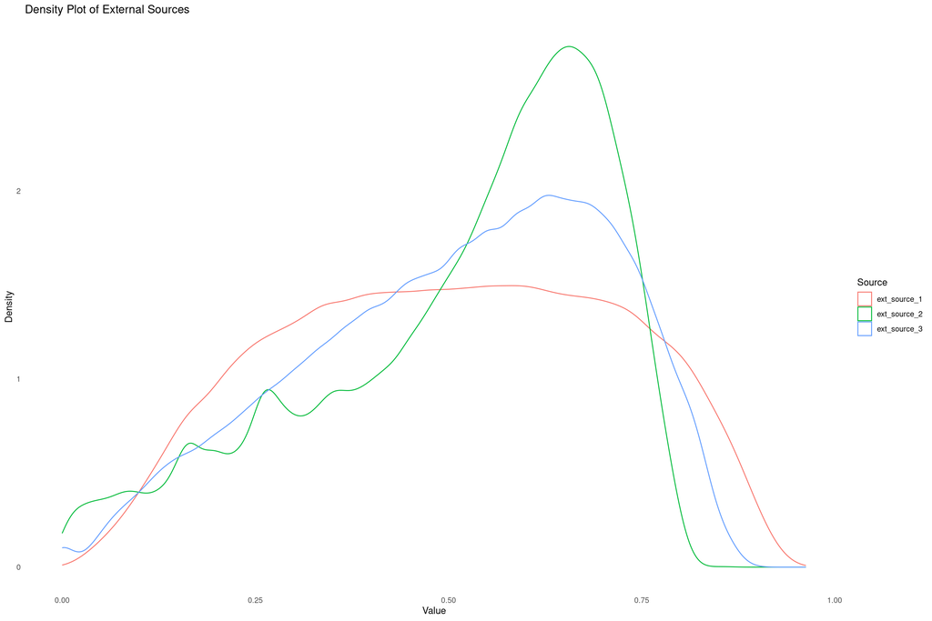

```r
# Reshape external source data for visualization of density distribution
ext_source_temp <- temp_train %>%
  select(ext_source_1, ext_source_2, ext_source_3) %>%
  pivot_longer(cols = everything(), names_to = "source", values_to = "value")

# Plot density distribution of external sources
ggplot(ext_source_temp, aes(x = value, color = source)) +
  geom_density(na.rm = TRUE) +
  labs(
    title = "Density Plot of External Sources",
    x = "Value",
    y = "Density",
    color = "Source"
  ) +
  theme_minimal() +
  theme(
    panel.grid = element_blank()
  )
```

```r
# Display imbalance summary for the temp_train dataset
datatable(validate_imbalances(temp_train, threshold = 50))
```

|  | column | missing_percentage | zero_percentage | most_frequent_value | most_frequent_percentage | sum_percentage |
| --- | --- | --- | --- | --- | --- | --- |
| 36 | cc_closed_contracts | 71.74 | 28.26 |  |  | 100 |
| 67 | flag_document_10 | 0 | 100 |  |  | 100 |
| 69 | flag_document_12 | 0 | 100 |  |  | 100 |
| 77 | flag_document_2 | 0 | 100 |  |  | 100 |
| 167 | prev_num_completed | 5.35 | 94.65 |  |  | 100 |
| 28 | bad_debt | 14.31 | 85.68 |  |  | 99.99000000000001 |
| 33 | cash_loan_nonearmarked | 14.31 | 85.68 |  |  | 99.99000000000001 |
| 103 | interbank_credit | 14.31 | 85.68 |  |  | 99.99000000000001 |
| 116 | loan_for_purchase_of_shares_margin_lending | 14.31 | 85.68 |  |  | 99.99000000000001 |
| 117 | loan_for_the_purchase_of_equipment | 14.31 | 85.68 |  |  | 99.99000000000001 |

[output cut: 216 more lines]

```r
# Clean and adjust specific columns in the dataset
temp_train <- temp_train %>%
  mutate(
    ext_source_1 = ifelse(is.na(ext_source_1), median(ext_source_1, na.rm = TRUE), ext_source_1),
    ext_source_2 = ifelse(is.na(ext_source_2), median(ext_source_2, na.rm = TRUE), ext_source_2),
    ext_source_3 = ifelse(is.na(ext_source_3), median(ext_source_3, na.rm = TRUE), ext_source_3),
    avg_cc_months_balance = abs(avg_cc_months_balance),
    avg_days_late = abs(avg_days_late),
    avg_p_c_months_balance = abs(avg_p_c_months_balance),
    days_birth = abs(days_birth),
    days_employed = abs(days_employed),
    days_id_publish = abs(days_id_publish),
    days_last_phone_change = abs(days_last_phone_change),
    days_registration = abs(days_registration),
    prev_avg_days_decision = abs(prev_avg_days_decision),
    prev_avg_days_termination = abs(prev_avg_days_termination),
    prev_last_app_days_ago = abs(prev_last_app_days_ago)
  ) %>%
  select(
    -flag_document_10,
    -flag_document_12,
    -flag_document_2,
    -flag_document_4,
    -flag_document_7,
    -flag_document_17,
    -flag_document_21,
    -flag_document_20,
    -flag_document_19,
    -flag_document_15,
    -flag_document_14,
    -flag_document_13,
    -flag_document_11,
    -flag_document_9,
    -flag_document_18,
    -flag_document_16,
    -flag_document_5,
    -cash_loan_nonearmarked,
    -loan_for_the_purchase_of_equipment,
    -loan_for_working_capital_replenishment,
    -unknown_type_of_loan,
    -another_type_of_loan,
    -loan_for_business_development,
    -amt_req_credit_bureau_day,
    -amt_req_credit_bureau_hour,
    -sum_bureau_status_4,
    -sum_bureau_status_5,
    -sum_bureau_status_3,
    -total_overdue,
    -max_cb_day_overdue,
    -microloan,
    -prev_avg_interest_primary,
    -prev_avg_interest_privileged,
    -accounts_sold,
    -sum_bureau_status_2,
    -amt_req_credit_bureau_week,
    -sum_recent_delinq_count,
    -mortgage,
    -cc_any_default,
    -total_cc_dpd,
    -car_loan,
    -def_60_cnt_social_circle,
    -sum_bureau_status_1,
    -flag_mobil,
    -flag_cont_mobile,
    -reg_region_not_live_region,
    -live_region_not_work_region,
    -reg_region_not_work_region,
    -prev_num_completed,
    -flag_email,
    -reg_city_not_live_city,
    -flag_document_8,
    -flag_document_6,
    -emergencystate_mode,
    -real_estate_loan,
    -bad_debt,
    -mobile_operator_loan,
    -loan_for_purchase_of_shares_margin_lending,
    -interbank_credit,
    -cc_closed_contracts
  )

# Perform quick cleaning on the dataset
temp_train <- temp_train %>%
  quick_clean()

# Convert temp_train back to a data.table for faster operations
setDT(temp_train)

# Display imbalance summary again after cleaning
datatable(validate_imbalances(temp_train, threshold = 50))
```

|  | column | missing_percentage | zero_percentage | most_frequent_value | most_frequent_percentage | sum_percentage |
| --- | --- | --- | --- | --- | --- | --- |
| 137 | target |  |  | No | 91.93 | 91.93 |
| 84 | name_contract_type |  |  | Cash loans | 90.48 | 90.48 |
| 18 | avg_delinq_ratio | 0 | 89.9 |  |  | 89.9 |
| 79 | max_delinq_ratio | 0 | 89.9 |  |  | 89.9 |
| 80 | max_dpd | 0 | 89.9 |  |  | 89.9 |
| 135 | sum_months_delinquent | 0 | 89.9 |  |  | 89.9 |
| 152 | total_ever_late | 0 | 89.9 |  |  | 89.9 |
| 148 | total_cc_pos_drawings | 0 | 88.88 |  |  | 88.88 |
| 87 | name_housing_type |  |  | House / apartment | 88.73 | 88.73 |
| 92 | nonlivingapartments_mode | 0 | 88.7 |  |  | 88.7 |

[output cut: 156 more lines]

# 7 Data Evaluation

## 7.1 Class Balance Analysis

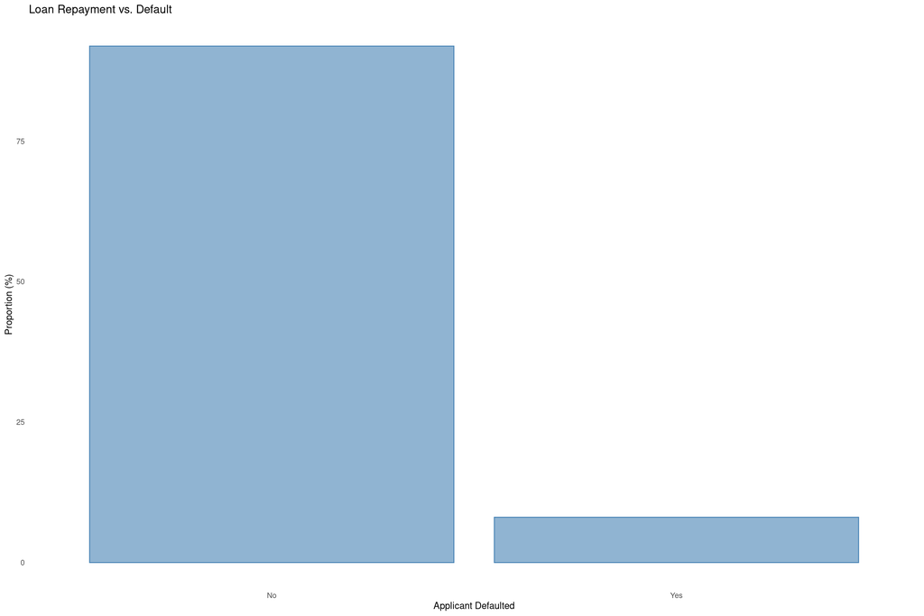

```r
# Prepare a data subset to evaluate any class imbalance in the target variable
target_summary <- temp_train %>%
  select(target) %>%
  count(target) %>%
  mutate(
    # Calculate the proportion of each class in the target variable
    proportion = round((n / sum(n)) * 100, 2),

    # Identify the majority class based on its proportion
    majority_class = if_else((n / sum(n)) >= 0.5, TRUE, FALSE)
  )

# Plot the class proportions to evaluate class distribution
ggplot(target_summary, aes(x = as.factor(target), y = proportion)) +
  geom_bar(
    stat = "identity",
    fill = "steelblue",
    color = "steelblue",
    alpha = 0.6
  ) +
  labs(
    title = "Loan Repayment vs. Default",  # Plot title
    x = "Applicant Defaulted",            # X-axis label
    y = "Proportion (%)"                   # Y-axis label
  ) +
  theme_minimal() +
  theme(
    panel.grid = element_blank(),
    panel.grid.major = element_blank(),
    panel.grid.minor = element_blank()
  )
```

Our assessment of the target variable indicates a significant class imbalance, with the majority class skewed toward non-default outcomes. If left unaddressed, this imbalance could cause models to bias heavily toward the majority class, resulting in incorrect predictions, misleading performance metrics and making it difficult to accurately evaluate and compare models. To mitigate this, we will consider strategies such as random sampling, oversampling the minority class, or undersampling the majority class during data preparation.

## 7.2 Application Reception Analysis

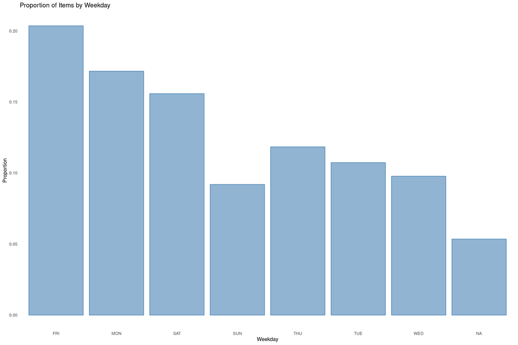

```r
# Calculate the proportion of items by weekday and plot the distribution
temp_train %>%
  count(prev_most_common_weekday) %>%
  mutate(
    prev_most_common_weekday = str_sub(prev_most_common_weekday, 1, 3),
    proportion = n / sum(n)
  ) %>%
  ggplot(aes(x = prev_most_common_weekday, y = proportion)) +
  geom_col(
    fill = "steelblue",
    color = "steelblue",
    alpha = 0.6
  ) +
  labs(
    title = "Proportion of Items by Weekday",
    x = "Weekday",
    y = "Proportion"
  ) +
  theme_minimal() +
  theme(
    panel.grid = element_blank(),
    panel.grid.major = element_blank(),
    panel.grid.minor = element_blank()
  )
```

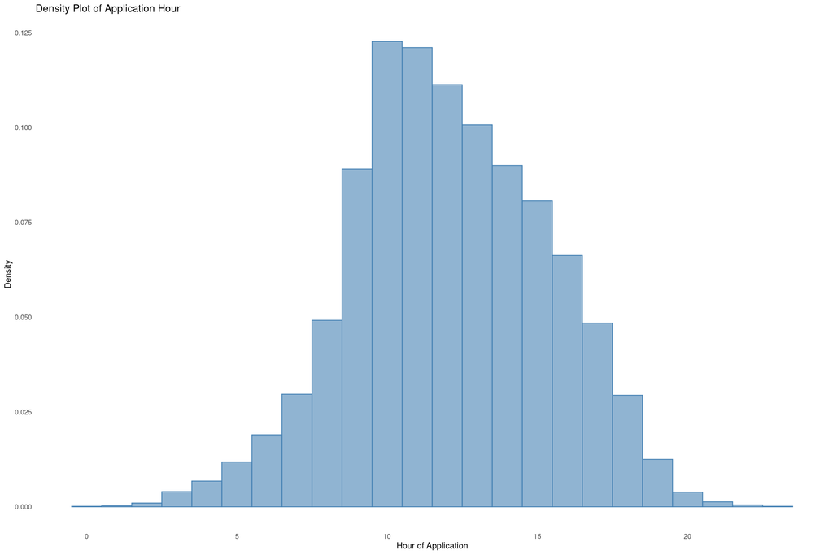

```r
# Prepare data for the histogram of the application process hour
processing_hour_temp <- temp_train %>%
  select(hour_appr_process_start) %>%
  pivot_longer(cols = everything(), names_to = "source", values_to = "value")

ggplot(processing_hour_temp, aes(x = value)) +
  geom_histogram(aes(y = after_stat(density)),
                 binwidth = 1,
                 color = "steelblue",
                 fill = "steelblue",
                 alpha = 0.6) +
  labs(
    title = "Density Plot of Application Hour",
    x = "Hour of Application",
    y = "Density"
  ) +
  theme_minimal() +
  theme(
    panel.grid = element_blank(),
    panel.grid.major = element_blank(),
    panel.grid.minor = element_blank()
  )
```

## 7.3 Amount Distributions Analysis

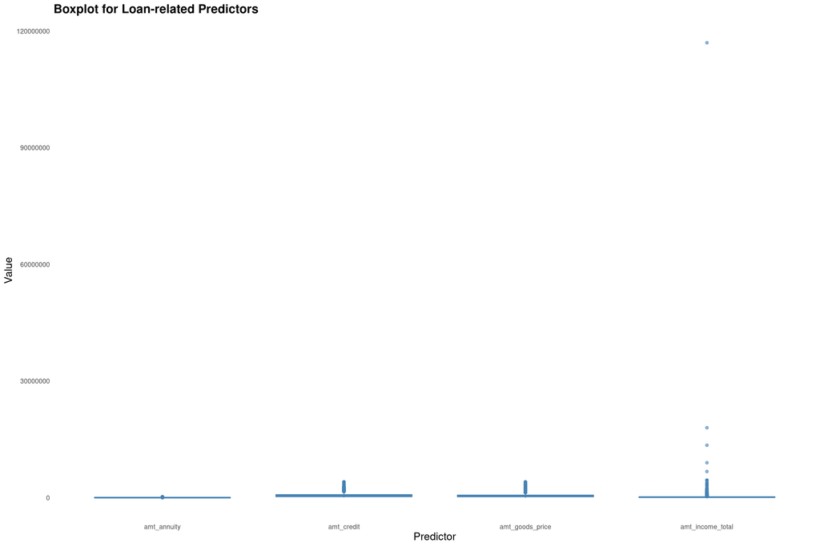

```r
# Reshape data into long format for grouped boxplot of loan-related predictors
temp_train_long <- temp_train %>%
  select(amt_annuity, amt_credit, amt_goods_price, amt_income_total) %>%
  pivot_longer(cols = everything(), names_to = "predictor", values_to = "value")

# Boxplot for the selected loan-related predictors
ggplot(temp_train_long, aes(x = predictor, y = value, fill = predictor)) +
  geom_boxplot(color = "steelblue", fill = "steelblue", alpha = 0.6) +  # Apply color theme
  labs(title = "Boxplot for Loan-related Predictors",
       x = "Predictor",
       y = "Value") +
  theme_minimal() +
  theme(
    axis.title.x = element_text(size = 14),
    axis.title.y = element_text(size = 14),
    plot.title = element_text(size = 16, face = "bold"),
    panel.grid = element_blank(),
    panel.grid.major = element_blank(),
    panel.grid.minor = element_blank()
  )
```

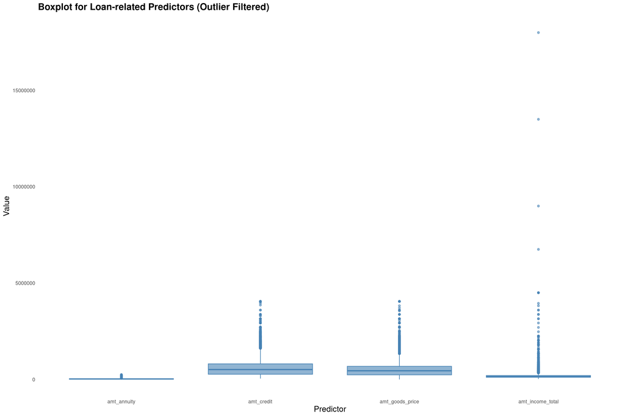

```r
# Filter out records where amt_income_total is an extreme outlier
temp_train_filtered <- temp_train %>%
  filter(amt_income_total < 6.0e+07)

# Reshape the filtered data into long format for grouped boxplot
temp_train_long_filtered <- temp_train_filtered %>%
  select(amt_annuity, amt_credit, amt_goods_price, amt_income_total) %>%
  pivot_longer(cols = everything(), names_to = "predictor", values_to = "value")

# Boxplot for the selected loan-related predictors after filtering out outliers
ggplot(temp_train_long_filtered, aes(x = predictor, y = value, fill = predictor)) +
  geom_boxplot(color = "steelblue", fill = "steelblue", alpha = 0.6) +  # Apply color theme
  labs(title = "Boxplot for Loan-related Predictors (Outlier Filtered)",
       x = "Predictor",
       y = "Value") +
  theme_minimal() +
  theme(
    axis.title.x = element_text(size = 14),
    axis.title.y = element_text(size = 14),
    plot.title = element_text(size = 16, face = "bold"),
    panel.grid = element_blank(),
    panel.grid.major = element_blank(),
    panel.grid.minor = element_blank()
  )
```

Based on our analysis of the loan amounts and applicant income, we observed a significant outlier in applicant income. This outlier has been removed in the second plot to allow for better visualization and comparison of the remaining amounts. Despite the removal of the outlier, a broad range of applicant income values remains, with the majority falling below the average values for the credit amounts provided and the cost of goods purchased. This suggests that the majority of applicants have relatively lower incomes in relation to the loan amounts they are seeking.

Furthermore, when comparing the amount of credit with the price of goods purchased, the distributions of both variables appear strikingly similar. This is an obvious assumption, as loans are often requested specifically to cover the cost of goods or services, and the two variables are likely to be closely tied in most cases, reinforcing the connection between the two.

The loan annuity, however, is less informative in this plot as it is overshadowed by the distributions of the other amounts.

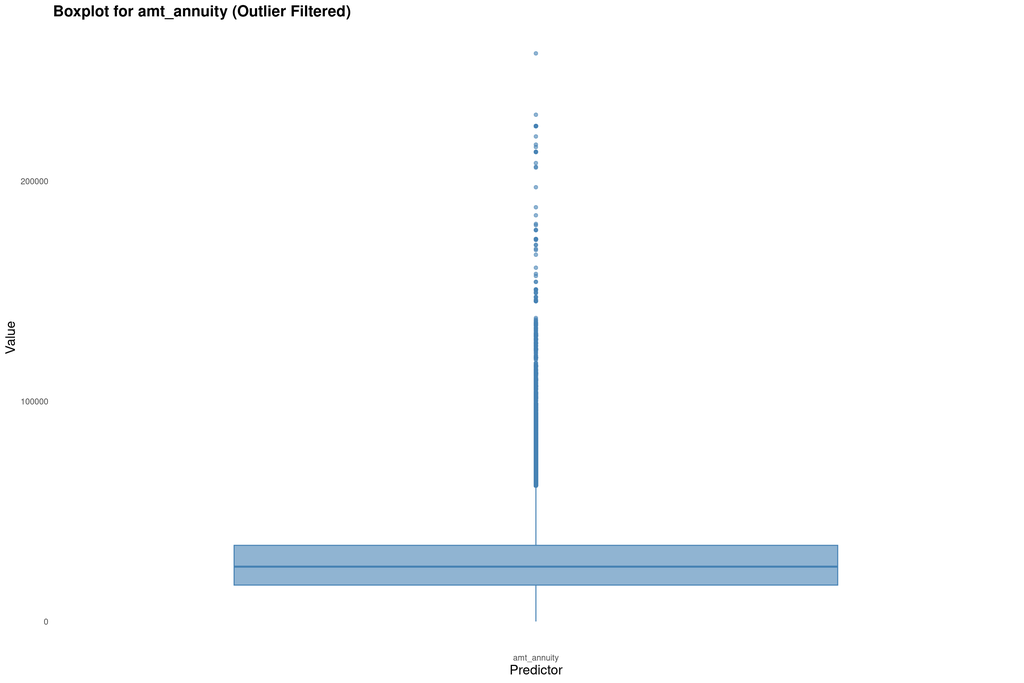

```r
# Reshape the data into long format for grouped boxplot (only for amt_annuity)
temp_train_long_filtered_amt_annuity <- temp_train_filtered %>%
  select(amt_annuity) %>%
  pivot_longer(cols = everything(), names_to = "predictor", values_to = "value")

# Boxplot for amt_annuity after filtering
ggplot(temp_train_long_filtered_amt_annuity, aes(x = predictor, y = value, fill = predictor)) +
  geom_boxplot(color = "steelblue", fill = "steelblue", alpha = 0.6) +  # Apply color theme
  labs(title = "Boxplot for amt_annuity (Outlier Filtered)",
       x = "Predictor",
       y = "Value") +
  theme_minimal() +
  theme(
    axis.title.x = element_text(size = 14),
    axis.title.y = element_text(size = 14),
    plot.title = element_text(size = 16, face = "bold"),
    panel.grid = element_blank(),
    panel.grid.major = element_blank(),
    panel.grid.minor = element_blank()
  )
```

The third plot, which focuses solely on loan annuity, provides additional insights. While it shows that many applications have annuity amounts exceeding $50,000, the vast majority of loans have annuity values below that threshold. This highlights that while some applicants may be seeking larger loan amounts, most loans are issued with more modest annuity values.

It is likely that the loans with more modest annuity values are also related to different types of loans. For instance, a mortgage loan would typically have a significantly higher annuity value compared to a simple personal loan, which would explain the variation in the distribution of annuity values. This suggests that the type of loan could be an important factor influencing the size of the annuity amount, and further segmentation by loan type could provide deeper insights into the loan issuance patterns.

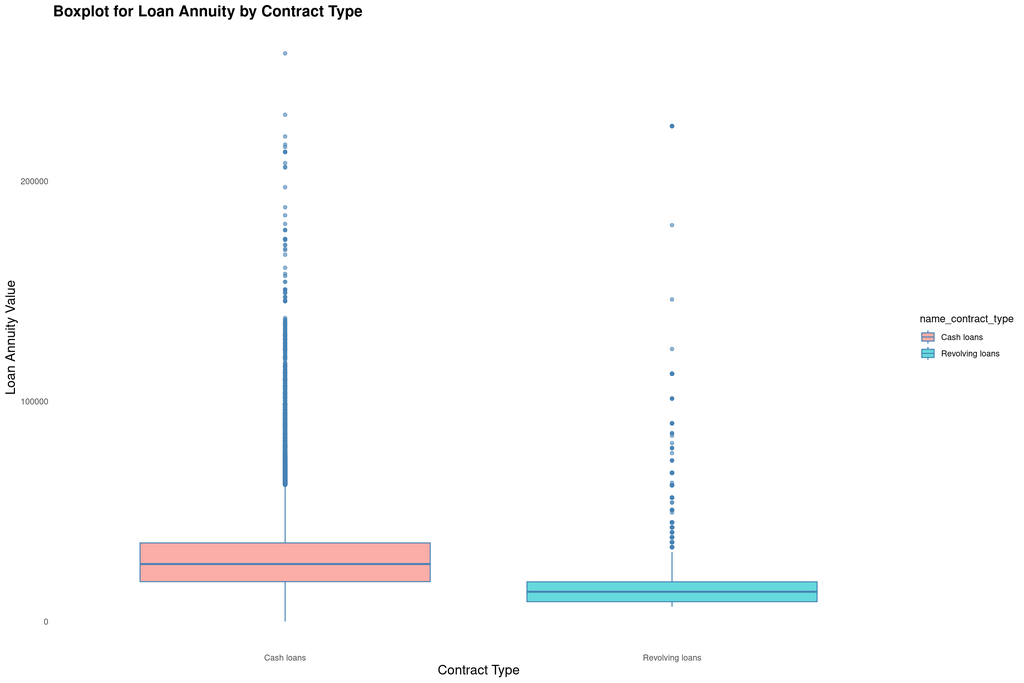

```r
# Filter dataset and pivot data for the selected financial columns and contract type
temp_train_filtered <- temp_train %>%
  filter(amt_income_total < 6.0e+07) %>%
  select(amt_annuity, amt_credit, amt_goods_price, amt_income_total, name_contract_type) %>%
  pivot_longer(cols = c(amt_annuity, amt_credit, amt_goods_price, amt_income_total),
               names_to = "predictor",
               values_to = "value")

# Create a boxplot for loan annuity, broken up by contract type
ggplot(temp_train_filtered[temp_train_filtered$predictor == "amt_annuity", ], aes(x = name_contract_type, y = value, fill = name_contract_type)) +
  geom_boxplot(color = "steelblue", alpha = 0.6) +
  labs(title = "Boxplot for Loan Annuity by Contract Type",
       x = "Contract Type",
       y = "Loan Annuity Value") +
  theme_minimal() +
  theme(
    axis.title.x = element_text(size = 14),
    axis.title.y = element_text(size = 14),
    plot.title = element_text(size = 16, face = "bold"),
    panel.grid = element_blank(),
    panel.grid.major = element_blank(),
    panel.grid.minor = element_blank()
  )
```

The forth plot further confirms our hypothesis regarding loan annuity distributions across contract types. It clearly shows that revolving loans tend to have fundamentally lower annuity values compared to cash loans, which aligns with the expected behavior: revolving loans often have more flexible repayment terms, leading to smaller, more manageable monthly payments. However, it’s important to note that this plot only distinguishes between revolving and cash loans. In reality, cash loans encompass a range of different loan types, and their annuity values can vary significantly. For instance, the annuity values for mortgage loans or business loans would likely be higher compared to personal cash loans, highlighting the need to consider further segmentation within the cash loan category. Thus, while the current visualization gives useful insights, additional categorization of loan types within the cash loan group could provide a more granular understanding of annuity distributions.

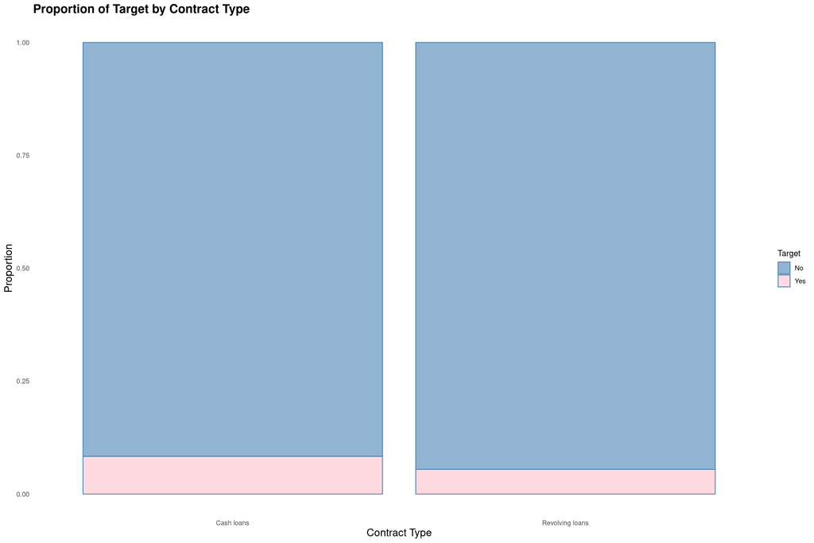

```r
# Simplify dataset to include only the contract type and target columns
temp_train_filtered <- temp_train %>%
  select(name_contract_type, target)

# Create a bar plot to visualize the proportion of target by contract type with custom colors
ggplot(temp_train_filtered, aes(x = name_contract_type, fill = as.factor(target))) +
  geom_bar(position = "fill", color = "steelblue", alpha = 0.6) +
  scale_fill_manual(values = c("No" = "steelblue", "Yes" = "pink")) +  # Set custom colors for target values
  labs(
    title = "Proportion of Target by Contract Type",
    x = "Contract Type",
    y = "Proportion",
    fill = "Target"
  ) +
  theme_minimal() +
  theme(
    axis.title.x = element_text(size = 14),
    axis.title.y = element_text(size = 14),
    plot.title = element_text(size = 16, face = "bold"),
    panel.grid = element_blank(),
    panel.grid.major = element_blank(),
    panel.grid.minor = element_blank()
  )
```

In our next plot, we have visualized the default rate by contract type, and it appears that cash loans have a higher default rate compared to revolving loans. This observation is an important consideration for our future loan default risk model. As previously mentioned, segmenting the data could enhance model performance, and the distinction between cash loans and revolving loans could be a useful segmentation. By training separate models for different segments, such as this one, we can better capture the unique risk profiles associated with each loan type, ultimately leading to more accurate predictions of loan defaults.

This information is highly valuable for Home Credit in understanding the distribution of loan annuities across different contract types. By identifying how annuity values vary between revolving loans and cash loans, and considering the potential impact of various loan types within the cash loan category, Home Credit can refine their loan offerings and better assess the financial capacity of applicants. Additionally, as we’ve observed in the previous analysis, cash loans tend to have a higher default rate than revolving loans, making it an important factor to consider when segmenting data for future model development. For the loan default risk model, this insight is crucial, as the loan annuity amount is likely to be a key feature. Loans with higher annuities may correlate with higher risk, particularly if the applicant’s income does not support the repayment terms. Incorporating these insights—such as distinguishing between revolving and cash loans, and considering loan types within each category—will help improve the model’s accuracy and enable more tailored and informed lending decisions.

## 7.4 Applicant Analysis

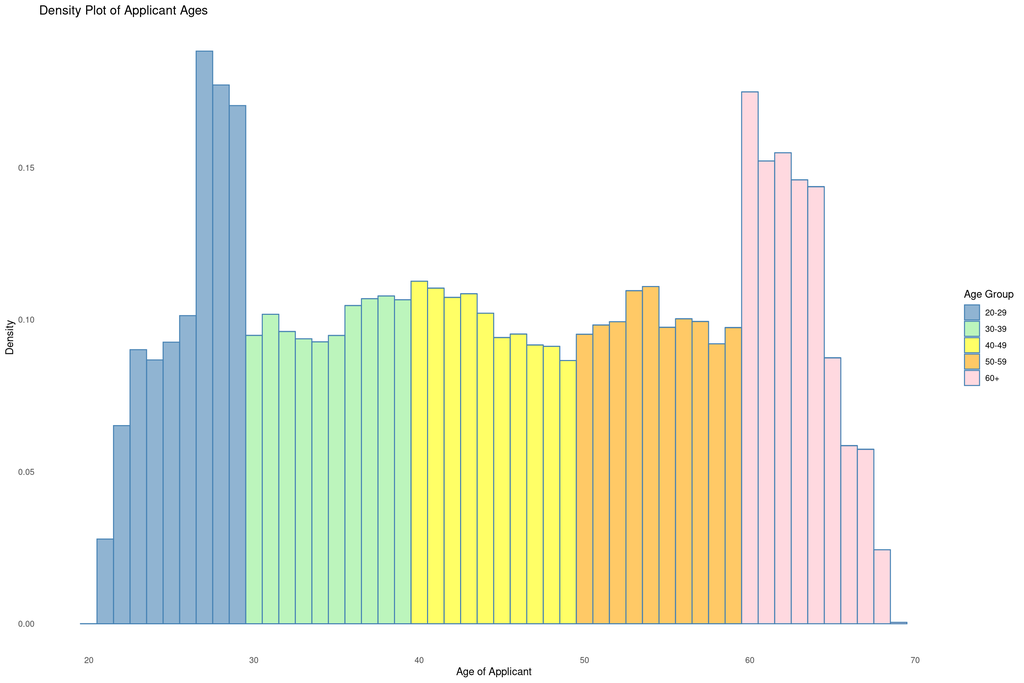

```r
# Create age categories based on 'days_birth' and add 'age_group' column
temp_train <- temp_train %>%
  mutate(age = floor(abs(days_birth) / 365),  # Convert days to age
         age_group = case_when(
           age < 20 ~ "Under 20",
           age >= 20 & age < 30 ~ "20-29",
           age >= 30 & age < 40 ~ "30-39",
           age >= 40 & age < 50 ~ "40-49",
           age >= 50 & age < 60 ~ "50-59",
           age >= 60 ~ "60+"  # Define age categories
         ))

# Convert 'age_group' to a factor with a specific order of levels
temp_train <- temp_train %>%
  mutate(age_group = factor(age_group, levels = c("Under 20", "20-29", "30-39", "40-49", "50-59", "60+")))

# Plotting age distribution by 'age_group' with density values
ggplot(temp_train, aes(x = age, fill = age_group)) +
  geom_histogram(aes(y = after_stat(density)),
                 binwidth = 1,
                 color = "steelblue",
                 alpha = 0.6) +
  labs(
    title = "Density Plot of Applicant Ages",
    x = "Age of Applicant",
    y = "Density",
    fill = "Age Group"
  ) +
  theme_minimal() +
  theme(
    panel.grid = element_blank(),
    panel.grid.major = element_blank(),
    panel.grid.minor = element_blank()
  ) +
  scale_fill_manual(values = c("Under 20" = "lightblue",
                               "20-29" = "steelblue",
                               "30-39" = "lightgreen",
                               "40-49" = "yellow",
                               "50-59" = "orange",
                               "60+" = "pink"))
```

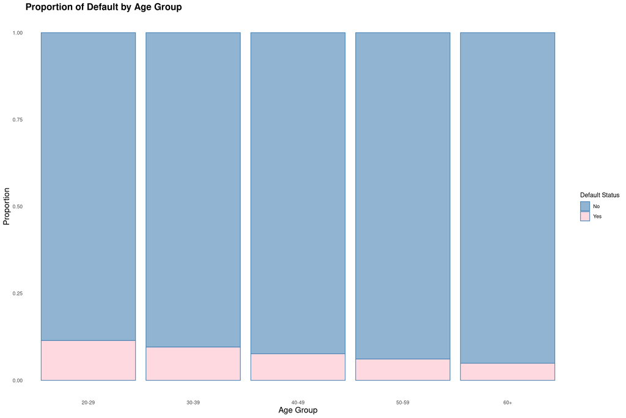

```r
# Re-create age categories and include 'target' based on default status
temp_train <- temp_train %>%
  mutate(age = floor(abs(days_birth) / 365),  # Convert days to age
         age_group = case_when(
           age < 20 ~ "Under 20",
           age >= 20 & age < 30 ~ "20-29",
           age >= 30 & age < 40 ~ "30-39",
           age >= 40 & age < 50 ~ "40-49",
           age >= 50 & age < 60 ~ "50-59",
           age >= 60 ~ "60+"  # Define age categories again for default status analysis
         ))

# Plotting the proportion of default status by 'age_group' with specific colors
ggplot(temp_train, aes(x = age_group, fill = target)) +
  geom_bar(position = "fill", color = "steelblue", alpha = 0.6) +
  scale_fill_manual(values = c("No" = "steelblue", "Yes" = "pink")) +  # Colors for "No" and "Yes" defaults
  labs(
    title = "Proportion of Default by Age Group",
    x = "Age Group",
    y = "Proportion",
    fill = "Default Status"
  ) +
  theme_minimal() +
  theme(
    axis.title.x = element_text(size = 14),
    axis.title.y = element_text(size = 14),
    plot.title = element_text(size = 16, face = "bold"),
    panel.grid = element_blank(),
    panel.grid.major = element_blank(),
    panel.grid.minor = element_blank()
  )
```

Upon analyzing the same age ranges in relation to the proportion of applicants who have defaulted versus those who have not, we observe a steady decline in default rates as applicants age. This is likely due to the increased income and financial stability that generally accompanies age, leading to a higher ability to repay loans. As individuals grow older, they typically experience more stable careers or access to retirement funds, reducing the likelihood of default.

Although Home Credit cannot directly use age as a feature in loan default decisions due to potential regulatory constraints, this analysis can still be valuable. Understanding the financial behavior of applicants from different age groups allows Home Credit to tailor their marketing strategies and product offerings. For example, they could focus on providing specific loan terms or promotional offers to younger applicants while ensuring older applicants are offered products that suit their financial stability and needs. Additionally, these insights can be used to refine customer segmentation, ultimately leading to better customer satisfaction and more effective targeting.

## 7.5 To be continued…

This evaluation is not complete and will to developed further to ensure a thorough evaluation of the data is performed.

# 8 Results